# Отток клиентов

Из «Бета-Банка» стали уходить клиенты. Каждый месяц. Немного, но заметно. Банковские маркетологи посчитали: сохранять текущих клиентов дешевле, чем привлекать новых.

Нужно спрогнозировать, уйдёт клиент из банка в ближайшее время или нет. Вам предоставлены исторические данные о поведении клиентов и расторжении договоров с банком.

Постройте модель с предельно большим значением *F1*-меры. Чтобы сдать проект успешно, нужно довести метрику до 0.59. Проверьте *F1*-меру на тестовой выборке самостоятельно.

Дополнительно измеряйте *AUC-ROC*, сравнивайте её значение с *F1*-мерой.

Источник данных: https://www.kaggle.com/barelydedicated/bank-customer-churn-modeling

## Стартовые параметры и ввод данных

```python
# Подключаем необходимые библиотеки

import pandas as pd
pd.options.mode.chained_assignment = None # чтобы пофиксить ошибку при масштабировании данных в sklearn

import matplotlib.pyplot as plt
import seaborn as sns
import os
import numpy as np

from sklearn.model_selection import train_test_split
from sklearn import linear_model, datasets
from sklearn.model_selection import GridSearchCV
from sklearn.utils import shuffle
from sklearn.preprocessing import StandardScaler
from sklearn.tree import DecisionTreeClassifier
from sklearn.ensemble import RandomForestClassifier
from sklearn.linear_model import LogisticRegression
from catboost import CatBoostClassifier
import lightgbm as lgb
import sklearn
from sklearn.utils.class_weight import compute_class_weight
from sklearn.metrics import (accuracy_score, confusion_matrix, ConfusionMatrixDisplay, f1_score,
                             roc_auc_score, roc_curve, recall_score, precision_score)

! pip install catboost --quiet
! pip install phik --quiet
! pip install lightgbm --quiet
! pip install shap --quiet
import phik
import shap

%matplotlib inline

pd.options.display.float_format = '{:.2f}'.format # отображать 2 знака после запятой
pd.options.display.max_columns = 50 # отображать до 50 колонок
pd.set_option('display.max_colwidth', 130) # увеличиваем максимальную ширину столбца, чтобы видеть больше данных (будут адреса)
```

```python
# Вводим классы для возможности лучшей визуализации
class color:
   BLUE = '\033[94m'
   GREEN = '\033[92m'
   RED = '\033[91m'
   BOLD = '\033[1m'
   UNDERLINE = '\033[4m'
   END = '\033[0m'
```

```python
# Функция загрузки данных из csv.
# На вход функция принимает два варианта пути (локальный/сервер). Загрузка происходит из доступного.
def import_data(pth_1, pth_2):
    if os.path.exists(pth_1):
        return pd.read_csv(pth_1, sep=',')
    elif os.path.exists(pth_2):
        return pd.read_csv(pth_2, sep=',')
    else:
        print('Загрузка данных неудачно. Нужно проверить, что пошло не так.')
```

```python
# Загружаем данные из 3-х источников
df = import_data('/datasets/Churn.csv', r'C:\Python\ML_bank\Churn.csv')
```

```python
df.head()
```

|  | RowNumber | CustomerId | Surname | CreditScore | Geography | Gender | Age | Tenure | Balance | NumOfProducts | HasCrCard | IsActiveMember | EstimatedSalary | Exited |
| --- | --- | --- | --- | --- | --- | --- | --- | --- | --- | --- | --- | --- | --- | --- |
| 0 | 1 | 15634602 | Hargrave | 619 | France | Female | 42 | 2.00 | 0.00 | 1 | 1 | 1 | 101348.88 | 1 |
| 1 | 2 | 15647311 | Hill | 608 | Spain | Female | 41 | 1.00 | 83807.86 | 1 | 0 | 1 | 112542.58 | 0 |
| 2 | 3 | 15619304 | Onio | 502 | France | Female | 42 | 8.00 | 159660.80 | 3 | 1 | 0 | 113931.57 | 1 |
| 3 | 4 | 15701354 | Boni | 699 | France | Female | 39 | 1.00 | 0.00 | 2 | 0 | 0 | 93826.63 | 0 |
| 4 | 5 | 15737888 | Mitchell | 850 | Spain | Female | 43 | 2.00 | 125510.82 | 1 | 1 | 1 | 79084.10 | 0 |

## Подготовка данных

### Функции раздела

#### Фуникция первичного знакомства с данными

```python
# Фуникция первичного знакомства с данными
# Функция, которая сразу выводит всю информацию, принимая на вход название датасета
def data_view(data):
    #Сразу приводим названия всех колонок к змеиному регистру.
    data.columns = data.columns. \
                                str.replace(r'([a-z0-9])([A-Z])' , r'\1_\2', regex = True). \
                                str.replace(r'(.)([A-Z][a-z]+)', r'\1_\2', regex = True). \
                                str.replace(r'([a-z0-9])([A-Z])', r'\1_\2', regex = True). \
                                str.replace(r'__([A-Z])', r'_\1', regex = True). \
                                str.replace(r'__([a-z0-9])', r'_\1', regex = True)
    data.columns = data.columns.str.lower()
    print()
    print(color.BLUE + color.BOLD + 'Первые 5 строк данных' + color.END)
    display(data.head()) # Выводим первые 5 строк
    print()
    print(color.BLUE + color.BOLD + 'Последние 5 строк данных' + color.END)
    display(data.tail()) # Выводим последние 5 строк
    print()
    print(color.BLUE + color.BOLD + 'Информация по датасету' + color.END)
    print()
    display(data.info()) # Выводим инфо по датасету
    print()
    # Уточняем количество пропусков по столбцам. Берем сумму пропусков и процентную долю пропусков
    print(color.BLUE + color.BOLD + 'Пропуски и уникальные значения (без учета пропусков)' + color.END)
    display(pd.concat([data.isna().sum().rename('nan_count'),
                       data.isna().mean().rename('nan_percent'),
                       data.nunique().rename('unique_values')],
                      axis=1).style.format({'nan_percent' : '{:.2%}'}))
    print()
    print(color.BLUE + color.BOLD + 'Дубликаты' + color.END)
    print()
    print('Количество явных дубликатов:', data.duplicated().sum())
    print('Доля явных дубликатов в данных: {:.2%}'.format((data.duplicated().sum())/len(data)))
    print()
```

#### Функция оптимизации занимаемой памяти

```python
def mem_usage(pandas_obj):
    '''Функция, измеряющая объем памяти, занимаемый датафреймом'''
    if isinstance(pandas_obj,pd.DataFrame):
        usage_b = pandas_obj.memory_usage(deep=True).sum()
    else: # исходим из предположения о том, что если это не DataFrame, то это Series
        usage_b = pandas_obj.memory_usage(deep=True)
    usage_mb = usage_b / 1024 # преобразуем байты в килобайты
    return round(usage_mb, 2)
```

```python
def data_optimize(df, object_option=False):
    '''
    Функция сокращающая объем занимаемой памяти входящего в нее датафрейма

    параметры
    ----------
    df: входящий датафрейм для оптимизации
    object_option : принимает значения True и False
        в случае true, конвертирует object в category

    возвращает
    -------
    df: датафрейм с оптимизированными типами данных
    '''

    print(color.BOLD + f'Объем памяти, занимаемый датафреймом до оптимизации {mem_usage(df)} Kb' + color.END)
    for col in df.columns:
        # для столбцов с типом данных float пробегаем и смотрим максимальное значение, оптимизируем тип
        if df[col].dtype == 'float':
            if pd.Series([df[col][i].is_integer() for i in range(len(df[col]))]).mean() == 1:
                df[col] = df[col].astype('int')
                col_min = df[col].min()
                col_max = df[col].max()
                if col_min >= 0:
                    if col_max < np.iinfo(np.uint8).max:
                        df[col] = df[col].astype(np.int16) # Не ставим минимальный uint8, чтобы была возможность вычислений
                    elif col_max < np.iinfo(np.uint16).max:
                        df[col] = df[col].astype(np.uint16)
                    elif col_max < np.iinfo(np.uint32).max:
                        df[col] = df[col].astype(np.uint32)
                    else:
                        df[col] = df[col]
                else:
                    if col_max < np.iinfo(np.int8).max and col_min > np.iinfo(np.int16).min:
                        df[col] = df[col].astype(np.int16)
                    elif col_max < np.iinfo(np.int16).max and col_min > np.iinfo(np.int16).min:
                        df[col] = df[col].astype(np.int16)
                    elif col_max < np.iinfo(np.int32).max and col_min > np.iinfo(np.int32).min:
                        df[col] = df[col].astype(np.int32)
                    else:
                        df[col] = df[col]
            else:
                col_min = df[col].min()
                col_max = df[col].max()
                if col_min > np.finfo(np.float32).min and col_max < np.finfo(np.float32).max:
                    df[col] = df[col].astype(np.float32)
                else:
                    df[col] = df[col]

        # для столбцов с типом данных int пробегаем и смотрим максимальное значение, оптимизируем тип
        elif df[col].dtype == 'int64':
            col_min = df[col].min()
            col_max = df[col].max()
            if col_min >= 0:
                if col_max < np.iinfo(np.uint8).max:
                    df[col] = df[col].astype(np.int16) # Не ставим минимальный uint8, чтобы была возможность вычислений
                elif col_max < np.iinfo(np.uint16).max:
                    df[col] = df[col].astype(np.uint16)
                elif col_max < np.iinfo(np.uint32).max:
                    df[col] = df[col].astype(np.uint32)
                else:
                    df[col] = df[col]
            else:
                if col_max < np.iinfo(np.int8).max and col_min > np.iinfo(np.int16).min:
                    df[col] = df[col].astype(np.int16)
                elif col_max < np.iinfo(np.int16).max and col_min > np.iinfo(np.int16).min:
                    df[col] = df[col].astype(np.int16)
                elif col_max < np.iinfo(np.int32).max and col_min > np.iinfo(np.int32).min:
                    df[col] = df[col].astype(np.int32)
                else:
                    df[col] = df[col]

        # для столбцов с типом данных float пробегаем и смотрим максимальное значение, оптимизируем тип
        elif df[col].dtype == 'float':
            col_min = df[col].min()
            col_max = df[col].max()
            if col_min > np.finfo(np.float32).min and col_max < np.finfo(np.float32).max:
                df[col] = df[col].astype(np.float32)
            else:
                df[col] = df[col]

        if object_option:
            if df[col].dtype == 'object':
                if len(df[col].value_counts()) < 0.5 * df.shape[0]:
                    df[col] = df[col].astype('category')
    print(color.BOLD + color.BLUE + f'Объем памяти, занимаемый датафреймом после оптимизации {mem_usage(df)} Mb' + color.END)
    return df.info()
```

### Знакомство с данными

Смотрим данные

```python
# Используем функцию data_view для знакомства с загруженными данными
data_view(df)
```

```
Первые 5 строк данных
```

|  | row_number | customer_id | surname | credit_score | geography | gender | age | tenure | balance | num_of_products | has_cr_card | is_active_member | estimated_salary | exited |
| --- | --- | --- | --- | --- | --- | --- | --- | --- | --- | --- | --- | --- | --- | --- |
| 0 | 1 | 15634602 | Hargrave | 619 | France | Female | 42 | 2.00 | 0.00 | 1 | 1 | 1 | 101348.88 | 1 |
| 1 | 2 | 15647311 | Hill | 608 | Spain | Female | 41 | 1.00 | 83807.86 | 1 | 0 | 1 | 112542.58 | 0 |
| 2 | 3 | 15619304 | Onio | 502 | France | Female | 42 | 8.00 | 159660.80 | 3 | 1 | 0 | 113931.57 | 1 |
| 3 | 4 | 15701354 | Boni | 699 | France | Female | 39 | 1.00 | 0.00 | 2 | 0 | 0 | 93826.63 | 0 |
| 4 | 5 | 15737888 | Mitchell | 850 | Spain | Female | 43 | 2.00 | 125510.82 | 1 | 1 | 1 | 79084.10 | 0 |

```
Последние 5 строк данных
```

|  | row_number | customer_id | surname | credit_score | geography | gender | age | tenure | balance | num_of_products | has_cr_card | is_active_member | estimated_salary | exited |
| --- | --- | --- | --- | --- | --- | --- | --- | --- | --- | --- | --- | --- | --- | --- |
| 9995 | 9996 | 15606229 | Obijiaku | 771 | France | Male | 39 | 5.00 | 0.00 | 2 | 1 | 0 | 96270.64 | 0 |
| 9996 | 9997 | 15569892 | Johnstone | 516 | France | Male | 35 | 10.00 | 57369.61 | 1 | 1 | 1 | 101699.77 | 0 |
| 9997 | 9998 | 15584532 | Liu | 709 | France | Female | 36 | 7.00 | 0.00 | 1 | 0 | 1 | 42085.58 | 1 |
| 9998 | 9999 | 15682355 | Sabbatini | 772 | Germany | Male | 42 | 3.00 | 75075.31 | 2 | 1 | 0 | 92888.52 | 1 |
| 9999 | 10000 | 15628319 | Walker | 792 | France | Female | 28 | NaN | 130142.79 | 1 | 1 | 0 | 38190.78 | 0 |

```
Информация по датасету

<class 'pandas.core.frame.DataFrame'>
RangeIndex: 10000 entries, 0 to 9999
Data columns (total 14 columns):
 #   Column            Non-Null Count  Dtype
---  ------            --------------  -----
 0   row_number        10000 non-null  int64
 1   customer_id       10000 non-null  int64
 2   surname           10000 non-null  object
 3   credit_score      10000 non-null  int64
 4   geography         10000 non-null  object
 5   gender            10000 non-null  object
 6   age               10000 non-null  int64
 7   tenure            9091 non-null   float64
 8   balance           10000 non-null  float64
 9   num_of_products   10000 non-null  int64
 10  has_cr_card       10000 non-null  int64
 11  is_active_member  10000 non-null  int64
 12  estimated_salary  10000 non-null  float64
 13  exited            10000 non-null  int64
dtypes: float64(3), int64(8), object(3)
memory usage: 1.1+ MB
```

```
None
```

```
Пропуски и уникальные значения (без учета пропусков)
```

|  | nan_count | nan_percent | unique_values |
| --- | --- | --- | --- |
| row_number | 0 | 0.00% | 10000 |
| customer_id | 0 | 0.00% | 10000 |
| surname | 0 | 0.00% | 2932 |
| credit_score | 0 | 0.00% | 460 |
| geography | 0 | 0.00% | 3 |
| gender | 0 | 0.00% | 2 |
| age | 0 | 0.00% | 70 |
| tenure | 909 | 9.09% | 11 |
| balance | 0 | 0.00% | 6382 |
| num_of_products | 0 | 0.00% | 4 |
| has_cr_card | 0 | 0.00% | 2 |
| is_active_member | 0 | 0.00% | 2 |
| estimated_salary | 0 | 0.00% | 9999 |
| exited | 0 | 0.00% | 2 |

```
Дубликаты

Количество явных дубликатов: 0
Доля явных дубликатов в данных: 0.00%
```

Загруженный датасет соответствует полученному в ТЗ описанию:

**Признаки**

- `RowNumber` — индекс строки в данных
- `CustomerId` — уникальный идентификатор клиента
- `Surname` — фамилия
- `CreditScore` — кредитный рейтинг
- `Geography` — страна проживания
- `Gender` — пол
- `Age` — возраст
- `Tenure` — сколько лет человек является клиентом банка
- `Balance` — баланс на счёте
- `NumOfProducts` — количество продуктов банка, используемых клиентом
- `HasCrCard` — наличие кредитной карты
- `IsActiveMember` — активность клиента
- `EstimatedSalary` — предполагаемая зарплата

**Целевой признак**

- `Exited` — факт ухода клиента

Первое же знакомство показывает:

- В данных есть 9% пропусков в поле Tendure (сколько лет клиент пользуется услугами банка). Данных достаточно много, требуется более подробный анализ.
- Поле row_number фактически дублирует индекс, его можно удалить.
- Наша задача - обучить ML-модель, поэтому поля customer_id и surname для нас так же не имеют полезного значения, т.к. они уникальны или специфичны для каждого клиента. Удалим эти поля, чтобы уменьшить датасет.

```python
# удаляем ненужные поля
df = df.drop(columns = ['row_number', 'customer_id', 'surname'], axis=1)
df.info()
```

```
<class 'pandas.core.frame.DataFrame'>
RangeIndex: 10000 entries, 0 to 9999
Data columns (total 11 columns):
 #   Column            Non-Null Count  Dtype
---  ------            --------------  -----
 0   credit_score      10000 non-null  int64
 1   geography         10000 non-null  object
 2   gender            10000 non-null  object
 3   age               10000 non-null  int64
 4   tenure            9091 non-null   float64
 5   balance           10000 non-null  float64
 6   num_of_products   10000 non-null  int64
 7   has_cr_card       10000 non-null  int64
 8   is_active_member  10000 non-null  int64
 9   estimated_salary  10000 non-null  float64
 10  exited            10000 non-null  int64
dtypes: float64(3), int64(6), object(2)
memory usage: 859.5+ KB
```

Рассмотрим подробнее количественные данные:

```python
df.describe()
```

|  | credit_score | age | tenure | balance | num_of_products | has_cr_card | is_active_member | estimated_salary | exited |
| --- | --- | --- | --- | --- | --- | --- | --- | --- | --- |
| count | 10000.00 | 10000.00 | 9091.00 | 10000.00 | 10000.00 | 10000.00 | 10000.00 | 10000.00 | 10000.00 |
| mean | 650.53 | 38.92 | 5.00 | 76485.89 | 1.53 | 0.71 | 0.52 | 100090.24 | 0.20 |
| std | 96.65 | 10.49 | 2.89 | 62397.41 | 0.58 | 0.46 | 0.50 | 57510.49 | 0.40 |
| min | 350.00 | 18.00 | 0.00 | 0.00 | 1.00 | 0.00 | 0.00 | 11.58 | 0.00 |
| 25% | 584.00 | 32.00 | 2.00 | 0.00 | 1.00 | 0.00 | 0.00 | 51002.11 | 0.00 |
| 50% | 652.00 | 37.00 | 5.00 | 97198.54 | 1.00 | 1.00 | 1.00 | 100193.91 | 0.00 |
| 75% | 718.00 | 44.00 | 7.00 | 127644.24 | 2.00 | 1.00 | 1.00 | 149388.25 | 0.00 |
| max | 850.00 | 92.00 | 10.00 | 250898.09 | 4.00 | 1.00 | 1.00 | 199992.48 | 1.00 |

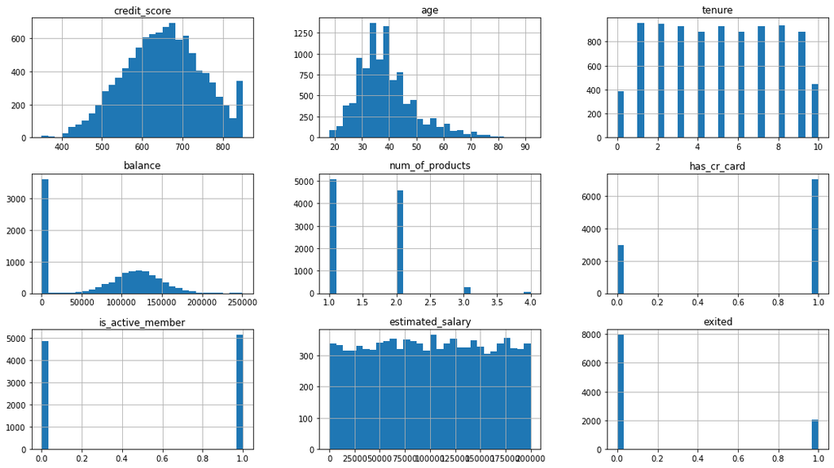

```python
# Смотрим распределение данных по количественным столбцам
df.hist(bins=30, figsize=(18, 10))
plt.show()
```

Анализ показывает, что имеющиеся у нас данные высокого качества. Явных аномалий или проблем не обнаруживается. Есть пик в районе 0 в поле баланс, но это полне объяснимо. Так же пик credit_score в районе максимума 850 несильно отличается от медианного значения, поэтому подозрений не вызывает. Немного смущает минимальная 'estimated_salary' = 11,58.

По целевому признаку `exited` мы наблюдаем дисбаланс классов.

```python
# Посмотрим 1, 3, 5, 10 перцентили по колонке ожидаемой зарплаты
print('Перцентили 1, 3, 5, 10 ожидаемой зарплаты составляют:\n',
      np.percentile(df['estimated_salary'], [1, 3, 5, 10]))
```

```
Перцентили 1, 3, 5, 10 ожидаемой зарплаты составляют:
 [ 1842.8253  5811.2985  9851.8185 20273.58  ]
```

Как мы видим, в этом признаке так же не наблюдается проблем с качеством данных. У нас вполне могут быть безработные, либо предприниматели/самозанятые, которые получили какую-то компенсацию, возврат налогов и т.д. Таких значений совсем мало, они на качество исследования не повлияют.

### Работа с пропусками

Посмотрим данные с пропусками:

```python
df[df['tenure'].isna()].sample(10)
```

|  | credit_score | geography | gender | age | tenure | balance | num_of_products | has_cr_card | is_active_member | estimated_salary | exited |
| --- | --- | --- | --- | --- | --- | --- | --- | --- | --- | --- | --- |
| 3628 | 493 | Germany | Female | 35 | NaN | 178317.60 | 1 | 0 | 0 | 197428.64 | 0 |
| 7018 | 805 | Germany | Male | 50 | NaN | 130023.38 | 1 | 1 | 0 | 62989.82 | 1 |
| 8630 | 706 | Germany | Female | 44 | NaN | 185932.18 | 2 | 1 | 0 | 65413.41 | 0 |
| 353 | 670 | Spain | Male | 25 | NaN | 0.00 | 2 | 1 | 1 | 78358.94 | 0 |
| 570 | 601 | France | Male | 44 | NaN | 100486.18 | 2 | 1 | 1 | 62678.53 | 0 |
| 2198 | 473 | Spain | Male | 48 | NaN | 0.00 | 2 | 1 | 0 | 71139.80 | 0 |
| 6755 | 812 | Spain | Male | 38 | NaN | 127117.80 | 2 | 1 | 1 | 174822.74 | 0 |
| 597 | 646 | Germany | Male | 39 | NaN | 111574.41 | 1 | 1 | 1 | 30838.51 | 0 |
| 1539 | 558 | France | Male | 38 | NaN | 113000.92 | 1 | 1 | 1 | 152872.39 | 0 |
| 8455 | 609 | France | Female | 53 | NaN | 0.00 | 2 | 1 | 1 | 124218.27 | 0 |

Какого-то характерного паттерна заметить не удалось. Попробуем посмотреть распределение данных:

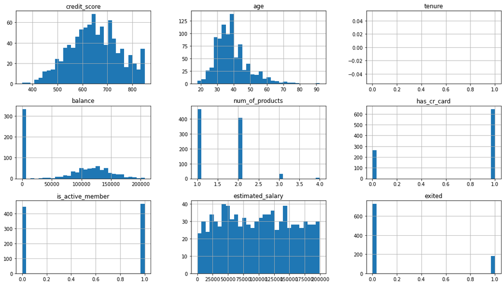

```python
# Смотрим распределение данных по количественным столбцам
df[df['tenure'].isna()].hist(bins=30, figsize=(18, 10))
plt.show()
```

Один из вариантов обработки - отбросить эти данные, и обучаться на оставшихся. Но 9% - это много, мы можем потерять большое количество важных фичей. Самый логичный вариант - заменить пропуски рандомными значениями, т.к. медиана в этом случае может создать ложный признак.

Попробуем посмотреть, есть ли какие-то зависимости (линейныеб нелинейные) между параметром `tenure` и остальными.

```python
# Смотрим линейную корреляцию по параметрам. Применяем цвет для наглядности
display(df.corr().style.background_gradient(cmap='coolwarm'))
```

|  | credit_score | age | tenure | balance | num_of_products | has_cr_card | is_active_member | estimated_salary | exited |
| --- | --- | --- | --- | --- | --- | --- | --- | --- | --- |
| credit_score | 1.000000 | -0.003965 | -0.000062 | 0.006268 | 0.012238 | -0.005458 | 0.025651 | -0.001384 | -0.027094 |
| age | -0.003965 | 1.000000 | -0.013134 | 0.028308 | -0.030680 | -0.011721 | 0.085472 | -0.007201 | 0.285323 |
| tenure | -0.000062 | -0.013134 | 1.000000 | -0.007911 | 0.011979 | 0.027232 | -0.032178 | 0.010520 | -0.016761 |
| balance | 0.006268 | 0.028308 | -0.007911 | 1.000000 | -0.304180 | -0.014858 | -0.010084 | 0.012797 | 0.118533 |
| num_of_products | 0.012238 | -0.030680 | 0.011979 | -0.304180 | 1.000000 | 0.003183 | 0.009612 | 0.014204 | -0.047820 |
| has_cr_card | -0.005458 | -0.011721 | 0.027232 | -0.014858 | 0.003183 | 1.000000 | -0.011866 | -0.009933 | -0.007138 |
| is_active_member | 0.025651 | 0.085472 | -0.032178 | -0.010084 | 0.009612 | -0.011866 | 1.000000 | -0.011421 | -0.156128 |
| estimated_salary | -0.001384 | -0.007201 | 0.010520 | 0.012797 | 0.014204 | -0.009933 | -0.011421 | 1.000000 | 0.012097 |
| exited | -0.027094 | 0.285323 | -0.016761 | 0.118533 | -0.047820 | -0.007138 | -0.156128 | 0.012097 | 1.000000 |

- Линейная корреляция между `tenure` и остальными практически отсутствует.
- По целевому признаку `exited` есть слабая положительная линейная корреляция по параметрам `age` и `balance`. Есть слабая отрицательная линейная корреляция по параметру `is_active_member`.

Попробуем посмотреть нелинейную корреляцию:

```python
# Смотрим линейную корреляцию по параметрам. Применяем цвет для наглядности
phik_overview = df.phik_matrix()
phik_overview['tenure'].sort_values(ascending=False)
```

```
interval columns not set, guessing: ['credit_score', 'age', 'tenure', 'balance', 'num_of_products', 'has_cr_card', 'is_active_member', 'estimated_salary', 'exited']
```

```
tenure             1.00
balance            0.06
num_of_products    0.06
age                0.05
has_cr_card        0.03
gender             0.03
is_active_member   0.03
exited             0.02
geography          0.00
credit_score       0.00
estimated_salary   0.00
Name: tenure, dtype: float64
```

Как мы видим, нелинейная связь между 'tenure' и остальными параметрами так же практически отсутствует. Поэтому заполнение рандомными значениями по всему датасету вполне оправдано.

```python
# Заполняем пропуски tenure рандомными значениями из имеющихся в датасете `tenure`
sample = df.loc[df['tenure'].notna(), 'tenure'].to_list() # отбираем непустые значения tenure

# Заполняем пропуски случайными значениями из встречающихся в tenure
np.random.seed(55)
df.loc[df['tenure'].isna(), 'tenure'] = df.loc[df['tenure'].isna(), 'tenure'].fillna(np.random.choice(sample))

# Смотрим результат
print()
print(color.BLUE + 'Количество пропусков tenure =' + color.END, df['tenure'].isna().mean())
display(df['tenure'].describe())
```

```
Количество пропусков tenure = 0.0
```

```
count   10000.00
mean        5.27
std         2.89
min         0.00
25%         3.00
50%         5.00
75%         8.00
max        10.00
Name: tenure, dtype: float64
```

Проблема с пропусками решена. Можно двигаться дальше.

### Подготовка данных к обучению

Оптимизируем типы данных:

```python
data_optimize(df)
```

```
Объем памяти, занимаемый датафреймом до оптимизации 1923.09 Kb
Объем памяти, занимаемый датафреймом после оптимизации 1434.81 Mb
<class 'pandas.core.frame.DataFrame'>
RangeIndex: 10000 entries, 0 to 9999
Data columns (total 11 columns):
 #   Column            Non-Null Count  Dtype
---  ------            --------------  -----
 0   credit_score      10000 non-null  uint16
 1   geography         10000 non-null  object
 2   gender            10000 non-null  object
 3   age               10000 non-null  int16
 4   tenure            10000 non-null  int16
 5   balance           10000 non-null  float32
 6   num_of_products   10000 non-null  int16
 7   has_cr_card       10000 non-null  int16
 8   is_active_member  10000 non-null  int16
 9   estimated_salary  10000 non-null  float32
 10  exited            10000 non-null  int16
dtypes: float32(2), int16(6), object(2), uint16(1)
memory usage: 371.2+ KB
```

Ранее мы уже установили, что линейная корреляция между признаками практически отсутствует. Посмотрим полную матрицу нелинейной корреляции:

```
interval columns not set, guessing: ['credit_score', 'age', 'tenure', 'balance', 'num_of_products', 'has_cr_card', 'is_active_member', 'estimated_salary', 'exited']
```

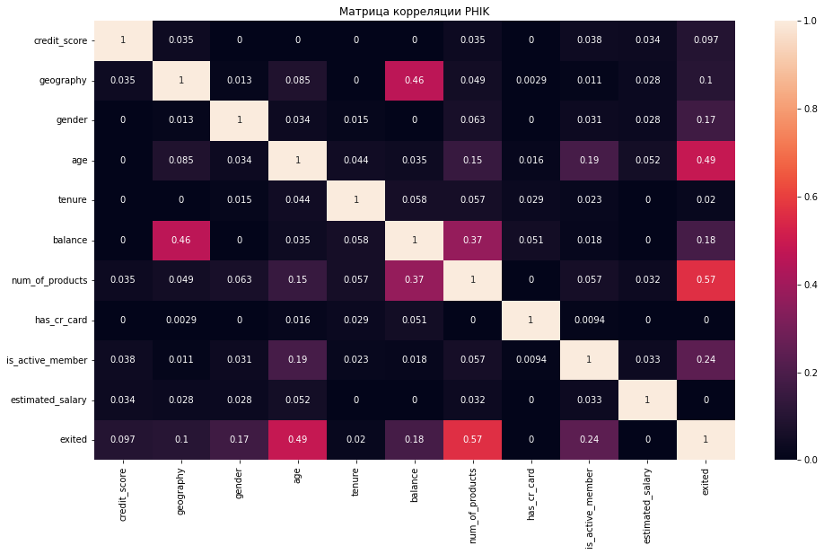

```python
phik_overview = df.phik_matrix()
plt.figure(figsize=(16,9))
plt.title('Матрица корреляции PHIK')
sns.heatmap(phik_overview, annot=True)
plt.show()
```

Мы видим, что обнаруживается нелинейная корреляция:

- между целевым параметром `exited` и признаками `age` и `num_of_products` достаточно высокая корреляция
- между целевым параметром `exited` и признаками `gender`, `balance` и `is_active_member` средняя корреляция

В столбцах `geography` и `gender` находятся категориальных признаки, которые до обучения моделей необходимо преобразовать. Используем для этой цели универсальный метод 'OHE' с опцией drop_first = True:

```python
# Применяем  one hot encoding
df_ohe = pd.get_dummies(df, drop_first=True)
# Смотрим результат
df_ohe.head()
```

|  | credit_score | age | tenure | balance | num_of_products | has_cr_card | is_active_member | estimated_salary | exited | geography_Germany | geography_Spain | gender_Male |
| --- | --- | --- | --- | --- | --- | --- | --- | --- | --- | --- | --- | --- |
| 0 | 619 | 42 | 2 | 0.00 | 1 | 1 | 1 | 101348.88 | 1 | 0 | 0 | 0 |
| 1 | 608 | 41 | 1 | 83807.86 | 1 | 0 | 1 | 112542.58 | 0 | 0 | 1 | 0 |
| 2 | 502 | 42 | 8 | 159660.80 | 3 | 1 | 0 | 113931.57 | 1 | 0 | 0 | 0 |
| 3 | 699 | 39 | 1 | 0.00 | 2 | 0 | 0 | 93826.63 | 0 | 0 | 0 | 0 |
| 4 | 850 | 43 | 2 | 125510.82 | 1 | 1 | 1 | 79084.10 | 0 | 0 | 1 | 0 |

Посмотрим матрицу нелинейной корреляции по подготовленным кодированным признакам:

```
interval columns not set, guessing: ['credit_score', 'age', 'tenure', 'balance', 'num_of_products', 'has_cr_card', 'is_active_member', 'estimated_salary', 'exited', 'geography_Germany', 'geography_Spain', 'gender_Male']
```

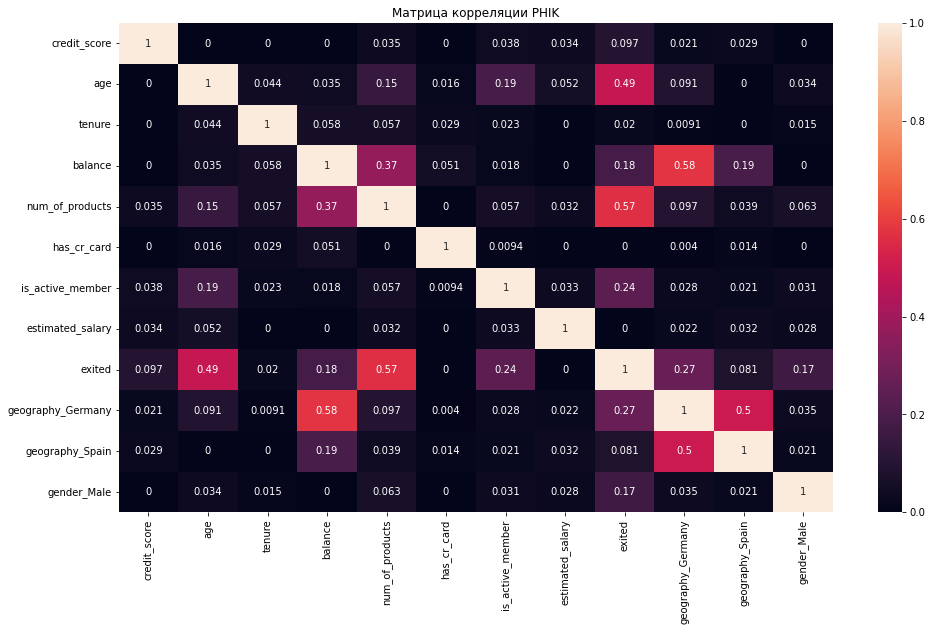

```python
phik_overview = df_ohe.phik_matrix()
plt.figure(figsize=(16,9))
plt.title('Матрица корреляции PHIK')
sns.heatmap(phik_overview, annot=True)
plt.show()
```

Из представленного графика видно, что в ранее не имеющем особых значений признаке `geography` нам удалось обнаружить средней силы связь по локации Германия и слабую нелинейную корреляцию по локации Испания.

### Разделение на train, valid, test

За неимением тетовой выборки мы будем разбивать исходные данные в соотношении 3:1:1. Размеры тестового и валидационного наборов обычно равны:

- обучающая выборка `60%`
- валидационная выборка `20%`
- тетсовая выборка `20%`

Разделим выборки методом train_test_split. Изначальная выборка у нас небольшая, всего 10000 строк, поэтому применим стратификацию целевого параметра, чтобы в выборках было равноценное распределение.

```python
features = df_ohe.drop(['exited'],axis=1) # отбираем признаки за исключением целевого
target = df_ohe['exited'] # извлеките целевой признак
# С помощью train_split_test отбираем данные для тестовой выборки
features_temp, features_test, target_temp, target_test = train_test_split(
    features, target, test_size=.20, random_state=42, stratify=target) # отделите 20% данных для тестовой выборки
# Теперь опять же train_split_test из оставшихся 80% данных отбираем данные для обучающей и валидационной выборки
features_train, features_valid, target_train, target_valid = train_test_split(
    features_temp, target_temp, test_size=.25, random_state=42, stratify=target_temp) # отделите 20% данных для тестовой выборки
```

Мы получили обучающую, валидационную и тестовую выборки в искомых соотношениях. Проверим, что не ошиблись. Для этого сложим количество строк в выделеных выборках. Оно должно быть равно изначальному количеству строк в `df_ohe`

```python
len(features_test)/len(df_ohe)
```

```
0.2
```

```python
print()
print(color.BLUE + color.BOLD + 'Количество строк в изначальном датафрейме:'+ color.END, len(df_ohe))
print(color.GREEN + color.BOLD +
      'Количество строк суммарно в обучающей, валидационной и тестовой выборках:'+ color.END,
      len(features_train)+len(features_valid)+len(features_test))
```

```
Количество строк в изначальном датафрейме: 10000
Количество строк суммарно в обучающей, валидационной и тестовой выборках: 10000
```

Сумма количества случаев в обучающей, валидационной и тестовой выборках соответствует количеству случаев в оригинальном датафрейме. Ошибок нет.

Ранее мы выяснили, что у нас неравноценное распределение по тарифам в изначальных данных. Проверим, соблюдается ли соотношение в выделенных выборках.

```python
print()
print(color.BLUE + color.BOLD + 'Соотношение актуалных/отточных клиентов в target_train:'+ color.END)
print(100 * target_train.value_counts(normalize=True))
print()
print(color.BLUE + color.BOLD + 'Соотношение актуалных/отточных клиентов в target_valid:'+ color.END)
print(100 * target_valid.value_counts(normalize=True))
print()
print(color.BLUE + color.BOLD + 'Соотношение актуалных/отточных клиентов в target_test:'+ color.END)
print(100 * target_test.value_counts(normalize=True))
```

```
Соотношение актуалных/отточных клиентов в target_train:
0   79.62
1   20.38
Name: exited, dtype: float64

Соотношение актуалных/отточных клиентов в target_valid:
0   79.65
1   20.35
Name: exited, dtype: float64

Соотношение актуалных/отточных клиентов в target_test:
0   79.65
1   20.35
Name: exited, dtype: float64
```

Соотношение целевого признака во всех выборках практически одинаково. Мы верно разделили данные, теперь можем приступать к построению моделей.

### Масштабирование признаков

```python
# Сохраняем немасштабированные фичи. Они нам еще потребуются
features_train_clr = features_train.copy()
features_valid_clr = features_valid.copy()
features_test_clr = features_test.copy()
```

Числовые данные в нашем датасете имеют разный масштаб. Чтобы исключить ложное влияние масштабов на результат обучения модели, применим масштабирование признаков с помощью метода `StandardScaler`

```python
# Отбираем количественные признаки
numeric = ['credit_score', 'age', 'tenure', 'num_of_products', 'balance', 'estimated_salary']

# Применяем метод масштабирования
scaler = StandardScaler()
scaler.fit(features_train[numeric])

# Масштабируем признаки
features_train[numeric] = scaler.transform(features_train[numeric])
features_valid[numeric] = scaler.transform(features_valid[numeric])
features_test[numeric] = scaler.transform(features_test[numeric])
```

```python
# смотрим результат
features_train.sample(5)
```

|  | credit_score | age | tenure | balance | num_of_products | has_cr_card | is_active_member | estimated_salary | geography_Germany | geography_Spain | gender_Male |
| --- | --- | --- | --- | --- | --- | --- | --- | --- | --- | --- | --- |
| 8992 | -0.45 | 0.10 | 0.94 | 0.71 | -0.91 | 0 | 0 | -0.67 | 1 | 0 | 0 |
| 9313 | 0.73 | -0.19 | -1.81 | 0.78 | -0.91 | 0 | 0 | 1.06 | 1 | 0 | 0 |
| 3025 | 1.12 | 0.00 | 0.25 | -1.24 | 0.80 | 1 | 1 | 0.72 | 0 | 0 | 0 |
| 7280 | 1.58 | 1.53 | 0.94 | -1.24 | 0.80 | 1 | 1 | 0.34 | 0 | 0 | 1 |
| 7035 | -0.96 | 1.63 | 0.59 | 0.71 | 0.80 | 1 | 1 | 0.29 | 0 | 0 | 0 |

Масштабирование признаков проведено успешно. Отрицательные значения, например, возраста - это лишь значения отклонений от среднего, полученные из формулы. Для обучения модели - то, что нужно.

## Исследование задачи

### Изучение баланса классов

```python
# Считаем долю сетевых от общего числа
print(color.BOLD + color. BLUE +
      'Доля отточных клиентов в датасете ='
      + color.END +' {:.1%} '.format(df_ohe['exited'].mean()))
```

```
Доля отточных клиентов в датасете = 20.4%
```

```python
print()
print(color.BLUE + color.BOLD + 'Соотношение актуалных/отточных клиентов в target_train:'+ color.END)
print(100 * target_train.value_counts(normalize=True))
print()
print(color.BLUE + color.BOLD + 'Соотношение актуалных/отточных клиентов в target_valid:'+ color.END)
print(100 * target_valid.value_counts(normalize=True))
print()
print(color.BLUE + color.BOLD + 'Соотношение актуалных/отточных клиентов в target_test:'+ color.END)
print(100 * target_test.value_counts(normalize=True))
```

```
Соотношение актуалных/отточных клиентов в target_train:
0   79.62
1   20.38
Name: exited, dtype: float64

Соотношение актуалных/отточных клиентов в target_valid:
0   79.65
1   20.35
Name: exited, dtype: float64

Соотношение актуалных/отточных клиентов в target_test:
0   79.65
1   20.35
Name: exited, dtype: float64
```

В целевом признаке присутствует дисбаланс классов: отточных клиентов в 4 раза меньше, чем актуальных

### Изучение моделей без балансировки классов

Напишем функцию вывода основных параметров

```python
# Функция вывода основных метрик
def show_metric(pred, name_of_model):
    # Считаем метрики, сохраняем в список
    temp = [['Accuracy', accuracy_score(target_valid, pred)],
             ['Recall', recall_score(target_valid, pred)],
             ['Precision', precision_score(target_valid, pred)],
             ['F1', f1_score(target_valid, pred)]
            ]
    # Преобразуем в датафрейм
    temp_df = (pd.DataFrame(temp, columns = ['variant_of_model', name_of_model])
               .set_index('variant_of_model').T
               )
    # Возвращаем результат
    return temp_df
```

#### Модель - DecisionTreeClassifier

```python
tree = None
best_f1_tree = 0
# Подбираем гиперпараметры в цикле, чтобы определить лучшие настройки модели
for depth in range(1, 21, 1):
    for spl in range(35, 101, 1):
        # инициализируем модель с параметром random_state=42. Параметр max_depth подбираем в цикле
        model = DecisionTreeClassifier(random_state=42, max_depth=depth, min_samples_leaf = 9, min_samples_split = spl)
        model.fit(features_train, target_train) # обучаем модель на тренировочной выборке
        predicted_valid = model.predict(features_valid) # получаем предсказания модели на валидационной выборке
        f1 = f1_score(target_valid, predicted_valid) # считаем f1-меру на валидационной выборке
        if f1 > best_f1_tree: # отбираем параметры модели с лучшим результатом f1-меры
            best_f1_tree = f1
            tree = model

predicted_tree = tree.predict(features_valid) # получаем предсказания лучшей модели на валидационной выборке

print()
print(color.BLUE + color.BOLD + "F1 наилучшей модели на валидационной выборке:" + color.END, best_f1_tree)
print()
print(color.BLUE + color.BOLD + "Параметры лучшей модели:" + color.END)
tree.get_params()
```

```
F1 наилучшей модели на валидационной выборке: 0.5810055865921787

Параметры лучшей модели:
```

```
{'ccp_alpha': 0.0,
 'class_weight': None,
 'criterion': 'gini',
 'max_depth': 14,
 'max_features': None,
 'max_leaf_nodes': None,
 'min_impurity_decrease': 0.0,
 'min_impurity_split': None,
 'min_samples_leaf': 9,
 'min_samples_split': 37,
 'min_weight_fraction_leaf': 0.0,
 'random_state': 42,
 'splitter': 'best'}
```

Смотрим основные параметры качества модели:

```python
tree_result = show_metric(predicted_tree, 'Tree_clear')
display(tree_result.style.format('{:.5f}'))
```

| variant_of_model | Accuracy | Recall | Precision | F1 |
| --- | --- | --- | --- | --- |
| Tree_clear | 0.85000 | 0.51106 | 0.67314 | 0.58101 |

Мы получили хорошие показатели **Accuracy - 0.85**, но при этом Полнота всего 0.511 и Точность всего 0.673. Совокупность этих параметров отражается в показателе **F1-меры - 0.581**.

Посмотрим матрицу ошибок:

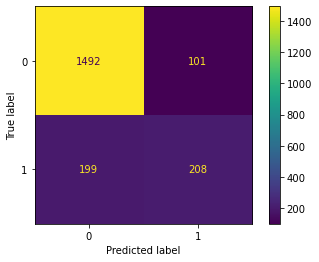

```
(1492, 101, 199, 208)
```

```python
cm = confusion_matrix(target_valid, predicted_tree)
ConfusionMatrixDisplay(confusion_matrix=cm).plot()
plt.show()
tn, fp, fn, tp = confusion_matrix(target_valid, predicted_tree).ravel()
tn, fp, fn, tp
```

#### Модель - RandomForestClassifier

```python
forest = None
best_f1_forest = 0
# Подбираем гиперпараметры в цикле, чтобы определить лучшие настройки модели
for est in range(41, 51, 1):
    for depth in range(20, 21, 1):
        model = RandomForestClassifier(random_state=42, max_depth=depth, n_estimators=est,
                                       min_samples_leaf = 1, min_samples_split = 2)
        model.fit(features_train, target_train) # обучаем модель на тренировочной выборке
        predicted_valid = model.predict(features_valid) # получаем предсказания модели на валидационной выборке
        f1 = f1_score(target_valid, predicted_valid) # считаем f1-меру на валидационной выборке
        if f1 > best_f1_forest: # отбираем параметры модели с лучшим результатом f1-меры
            best_f1_forest = f1
            forest = model

predicted_forest = forest.predict(features_valid) # получаем предсказания лучшей модели на валидационной выборке

print()
print(color.BLUE + color.BOLD + "F1 наилучшей модели на валидационной выборке:" + color.END, best_f1_forest)
print()
print(color.BLUE + color.BOLD + "Параметры лучшей модели:" + color.END)
forest.get_params()
```

```
F1 наилучшей модели на валидационной выборке: 0.5963855421686747

Параметры лучшей модели:
```

```
{'bootstrap': True,
 'ccp_alpha': 0.0,
 'class_weight': None,
 'criterion': 'gini',
 'max_depth': 20,
 'max_features': 'auto',
 'max_leaf_nodes': None,
 'max_samples': None,
 'min_impurity_decrease': 0.0,
 'min_impurity_split': None,
 'min_samples_leaf': 1,
 'min_samples_split': 2,
 'min_weight_fraction_leaf': 0.0,
 'n_estimators': 43,
 'n_jobs': None,
 'oob_score': False,
 'random_state': 42,
 'verbose': 0,
 'warm_start': False}
```

Смотрим основные параметры качества модели:

```python
forest_result = show_metric(predicted_forest, 'RandomForest_clear')
sum_result = pd.concat([tree_result, forest_result])
display(sum_result.style.format('{:.5f}'))
```

| variant_of_model | Accuracy | Recall | Precision | F1 |
| --- | --- | --- | --- | --- |
| Tree_clear | 0.85000 | 0.51106 | 0.67314 | 0.58101 |
| RandomForest_clear | 0.86600 | 0.48649 | 0.77043 | 0.59639 |

Мы получили отличный показатель **Accuracy - 0.866**, но при этом Полнота всего 0.487. Однако Точность намного выше, чем у дерева решений и составляет 0.77. Совокупность этих параметров отражается в показателе **F1-меры - 0.596**. Скорее всего такая картина обусловлена дисбалансом классов целевого признака, и качество модели можно еще улучшить.

#### Модель - LogisticRegression

```python
# Составляем массивы значений гиперпараметров
C = np.logspace(0, 10, num=20)
penalty = ['l1', 'l2']
solver = ['liblinear', 'saga']
# Составляем словарь гиперпараметров для GridSearchCV
hyperparameters = dict(C=C, penalty=penalty, solver=solver)

# Обучаем логистическую регрессию с помощью GridSearchCV
logistic = linear_model.LogisticRegression(random_state=42) # инициализируем модель
gridsearch = GridSearchCV(logistic, hyperparameters) # подбираем параметры
best_logistic = gridsearch.fit(features_train, target_train) # сохраняем лучшую модель

predicted_logistic = best_logistic.predict(features_valid) # получаем предсказания лучшей модели на валидационной выборке
f1_logistic = f1_score(target_valid, predicted_logistic)

print()
print(color.BLUE + color.BOLD + "F1 наилучшей модели на валидационной выборке:" + color.END, f1_logistic)
print()
print(color.BLUE + color.BOLD + "Параметры лучшей модели:" + color.END)
best_logistic.get_params()
```

```
F1 наилучшей модели на валидационной выборке: 0.31842576028622543

Параметры лучшей модели:
```

```
{'cv': None,
 'error_score': nan,
 'estimator__C': 1.0,
 'estimator__class_weight': None,
 'estimator__dual': False,
 'estimator__fit_intercept': True,
 'estimator__intercept_scaling': 1,
 'estimator__l1_ratio': None,
 'estimator__max_iter': 100,
 'estimator__multi_class': 'auto',
 'estimator__n_jobs': None,
 'estimator__penalty': 'l2',
 'estimator__random_state': 42,
 'estimator__solver': 'lbfgs',
 'estimator__tol': 0.0001,
 'estimator__verbose': 0,
 'estimator__warm_start': False,
 'estimator': LogisticRegression(random_state=42),
 'n_jobs': None,
 'param_grid': {'C': array([1.00000000e+00, 3.35981829e+00, 1.12883789e+01, 3.79269019e+01,
         1.27427499e+02, 4.28133240e+02, 1.43844989e+03, 4.83293024e+03,
         1.62377674e+04, 5.45559478e+04, 1.83298071e+05, 6.15848211e+05,
         2.06913808e+06, 6.95192796e+06, 2.33572147e+07, 7.84759970e+07,
         2.63665090e+08, 8.85866790e+08, 2.97635144e+09, 1.00000000e+10]),
  'penalty': ['l1', 'l2'],
  'solver': ['liblinear', 'saga']},
 'pre_dispatch': '2*n_jobs',
 'refit': True,
 'return_train_score': False,
 'scoring': None,
 'verbose': 0}
```

Смотрим основные параметры качества модели:

```python
logistic_result = show_metric(predicted_logistic, 'LogisticRegression_clear')
sum_result = pd.concat([sum_result, logistic_result])
display(sum_result.style.format('{:.5f}'))
```

| variant_of_model | Accuracy | Recall | Precision | F1 |
| --- | --- | --- | --- | --- |
| Tree_clear | 0.85000 | 0.51106 | 0.67314 | 0.58101 |
| RandomForest_clear | 0.86600 | 0.48649 | 0.77043 | 0.59639 |
| LogisticRegression_clear | 0.80950 | 0.21867 | 0.58553 | 0.31843 |

В модели логистической регрессии мы получили результаты сильно хуже предыдущих моделей.

#### Модель - CatBoostClassifier

```python
# инициализируем модель CatBoostClassifier
catb = CatBoostClassifier(
    leaf_estimation_method = 'Gradient',
    max_depth = 8,
    bootstrap_type = 'Bernoulli',
    objective = 'MultiClass',
    subsample = 0.9,
    random_state=42,
    iterations=1000,
    learning_rate=0.05,
    eval_metric='TotalF1',
    early_stopping_rounds = 100,
    verbose = 0
)

# обучаем модель
catb.fit(features_train, target_train, eval_set=(features_valid, target_valid))

predicted_catb = catb.predict(features_valid) # получаем предсказания модели на валидационной выборке
f1_catb = f1_score(target_valid, predicted_catb)

print()
print(color.BLUE + color.BOLD + "F1 наилучшей модели на валидационной выборке:" + color.END, f1_catb)
print()
print(color.BLUE + color.BOLD + "Параметры лучшей модели:" + color.END)
catb.get_params()
```

```
F1 наилучшей модели на валидационной выборке: 0.6069802731411229

Параметры лучшей модели:
```

```
{'iterations': 1000,
 'learning_rate': 0.05,
 'leaf_estimation_method': 'Gradient',
 'verbose': 0,
 'eval_metric': 'TotalF1',
 'bootstrap_type': 'Bernoulli',
 'subsample': 0.9,
 'max_depth': 8,
 'random_state': 42,
 'objective': 'MultiClass',
 'early_stopping_rounds': 100}
```

Смотрим основные параметры качества модели:

```python
catb_result = show_metric(predicted_catb, 'CatBoost_clear')
sum_result = pd.concat([sum_result, catb_result])
display(sum_result.style.format('{:.5f}'))
```

| variant_of_model | Accuracy | Recall | Precision | F1 |
| --- | --- | --- | --- | --- |
| Tree_clear | 0.85000 | 0.51106 | 0.67314 | 0.58101 |
| RandomForest_clear | 0.86600 | 0.48649 | 0.77043 | 0.59639 |
| LogisticRegression_clear | 0.80950 | 0.21867 | 0.58553 | 0.31843 |
| CatBoost_clear | 0.87050 | 0.49140 | 0.79365 | 0.60698 |

Мы получили отличный показатель **Accuracy - 0.871**, но при этом Полнота всего 0.491. Однако Точность намного выше, чем у дерева решений и составляет 0.794. Совокупность этих параметров отражается в показателе **F1-меры - 0.607**. Скорее всего такая картина обусловлена дисбалансом классов целевого признака, и качество модели можно еще улучшить.

#### Модель - LightGBM

```python
lgbm = lgb.LGBMClassifier(objective="binary",
                          n_estimators=1000,
                          random_state=42,
                          learning_rate=0.04,
                          early_stopping_rounds = 100,
                          verbose = -1
                         )

lgbm.fit(features_train, target_train, eval_set=[(features_valid, target_valid),])

predicted_lgbm = lgbm.predict(features_valid) # получаем предсказания модели на валидационной выборке
f1_lgbm = f1_score(target_valid, predicted_lgbm)
```

[output not shown]

[output cut: 201 more lines]

[output not shown]

```python
print()
print(color.BLUE + color.BOLD + "F1 наилучшей модели на валидационной выборке:" + color.END, f1_lgbm)
print()
print(color.BLUE + color.BOLD + "Параметры лучшей модели:" + color.END)
lgbm.get_params()
```

```
F1 наилучшей модели на валидационной выборке: 0.5923664122137404

Параметры лучшей модели:
```

```
{'boosting_type': 'gbdt',
 'class_weight': None,
 'colsample_bytree': 1.0,
 'importance_type': 'split',
 'learning_rate': 0.04,
 'max_depth': -1,
 'min_child_samples': 20,
 'min_child_weight': 0.001,
 'min_split_gain': 0.0,
 'n_estimators': 1000,
 'n_jobs': -1,
 'num_leaves': 31,
 'objective': 'binary',
 'random_state': 42,
 'reg_alpha': 0.0,
 'reg_lambda': 0.0,
 'silent': 'warn',
 'subsample': 1.0,
 'subsample_for_bin': 200000,
 'subsample_freq': 0,
 'early_stopping_rounds': 100,
 'verbose': -1}
```

Смотрим основные параметры качества модели:

```python
lgbm_result = show_metric(predicted_lgbm, 'LightGBM_clear')
sum_result = pd.concat([sum_result, lgbm_result])
display(sum_result.style.format('{:.5f}'))
```

| variant_of_model | Accuracy | Recall | Precision | F1 |
| --- | --- | --- | --- | --- |
| Tree_clear | 0.85000 | 0.51106 | 0.67314 | 0.58101 |
| RandomForest_clear | 0.86600 | 0.48649 | 0.77043 | 0.59639 |
| LogisticRegression_clear | 0.80950 | 0.21867 | 0.58553 | 0.31843 |
| CatBoost_clear | 0.87050 | 0.49140 | 0.79365 | 0.60698 |
| LightGBM_clear | 0.86650 | 0.47666 | 0.78226 | 0.59237 |

Модель LGBMClassifier отличается высокой скоростью работы и неплохими результатами. **Accuracy - 0.86**, Полнота всего 0.477. Точность - 0.782. Совокупность этих параметров отражается в показателе **F1-меры - 0.592**. В ходе подбора параметров нам удавалось добиться намного большей Precision, но при этом страдала полнота Recall. Возможно будет лучше после устранения дисбаланса классов.

### ROC-кривая. AUC-ROC

Построим кривую ошибок, чтобы оценить, насколько лучше наши модели, чем случайные предсказания. Чем больше площадь фигуры под кривой, тем выше качество предсказаний.

Посчитаем AUC_ROC (от англ. Area Under Curve ROC, «площадь под ROC-кривой») для обученных моделей, чтобы детально оценить качество моделей.

```python
# Считаем предсказания вероятностей для моделей
predicted_prob_tree = tree.predict_proba(features_valid)[:, 1]
predicted_prob_forest = forest.predict_proba(features_valid)[:, 1]
predicted_prob_logistic = best_logistic.predict_proba(features_valid)[:, 1]
predicted_prob_catb = catb.predict_proba(features_valid)[:, 1]
predicted_prob_lgbm = lgbm.predict_proba(features_valid)[:, 1]

# Выводим значения AUC_ROC
print('AUC_ROC DecisionTreeClassifier:', roc_auc_score(target_valid, predicted_prob_tree))
print('AUC_ROC RandomForestClassifier:', roc_auc_score(target_valid, predicted_prob_forest))
print('AUC_ROC LogisticRegression:', roc_auc_score(target_valid, predicted_prob_logistic))
print('AUC_ROC CatBoostClassifier:', roc_auc_score(target_valid, predicted_prob_catb))
print('AUC_ROC LGBMClassifier:', roc_auc_score(target_valid, predicted_prob_lgbm))
```

```
AUC_ROC DecisionTreeClassifier: 0.8229701195802891
AUC_ROC RandomForestClassifier: 0.8462553462553462
AUC_ROC LogisticRegression: 0.7558390439746372
AUC_ROC CatBoostClassifier: 0.8647692376505937
AUC_ROC LGBMClassifier: 0.8646227120803391
```

Визуализируем данные:

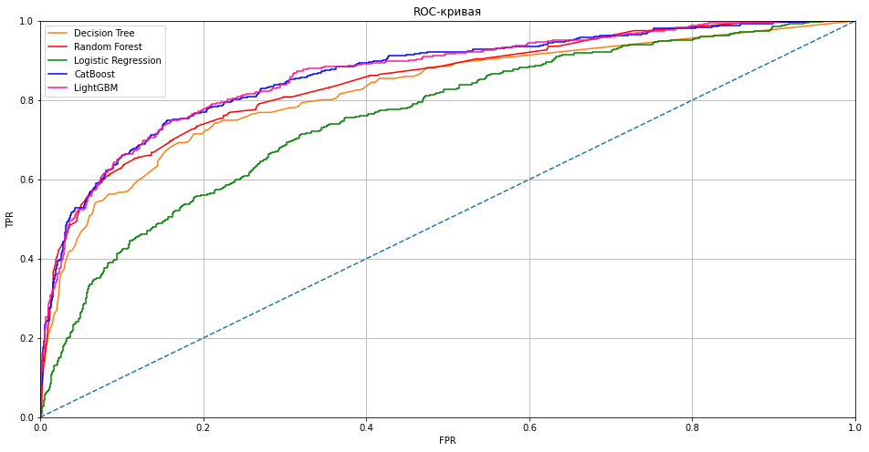

```python
# Строим графики ROC-кривых
plt.figure(figsize=(16, 8))
plt.xlim(0, 1)
plt.ylim(0, 1)
plt.title('ROC-кривая')
plt.xlabel('FPR')
plt.ylabel('TPR')
plt.grid()
plt.plot([0, 1], [0, 1], linestyle='--')
fpr, tpr, thresholds = roc_curve(target_valid, predicted_prob_tree)
plt.plot(fpr, tpr, label='Decision Tree')
fpr, tpr, thresholds = roc_curve(target_valid, predicted_prob_forest)
plt.plot(fpr, tpr, color='red', label='Random Forest')
fpr, tpr, thresholds = roc_curve(target_valid, predicted_prob_logistic)
plt.plot(fpr, tpr, color='green', label='Logistic Regression')
fpr, tpr, thresholds = roc_curve(target_valid, predicted_prob_catb)
plt.plot(fpr, tpr, color='blue', label='CatBoost')
fpr, tpr, thresholds = roc_curve(target_valid, predicted_prob_lgbm)
plt.plot(fpr, tpr, color='deeppink', label='LightGBM')
plt.legend()
plt.show()
```

- Анализ AUC-ROC показал, что лучшие предсказания дают модели CatBoost и LightGBM. При этом мы помним, что показатели Accuracy и F1-меры у CatBoost - лучшие.
- Третье место с очень близким результатом AUC-ROC у Random Forest.

### Выводы этапа

В имеющихся данных наблюдается дисбаланс классов: доля отточных клиентов в датасете = 20.4% (отточных клиентов в 4 раза меньше, чем актуальных).

Нам удалось получить следующие показатели для различных моделей:

```python
display(sum_result.sort_values('F1', ascending=False).style.format('{:.5f}'))
```

| variant_of_model | Accuracy | Recall | Precision | F1 |
| --- | --- | --- | --- | --- |
| CatBoost_clear | 0.87050 | 0.49140 | 0.79365 | 0.60698 |
| RandomForest_clear | 0.86600 | 0.48649 | 0.77043 | 0.59639 |
| LightGBM_clear | 0.86650 | 0.47666 | 0.78226 | 0.59237 |
| Tree_clear | 0.85000 | 0.51106 | 0.67314 | 0.58101 |
| LogisticRegression_clear | 0.80950 | 0.21867 | 0.58553 | 0.31843 |

Анализ AUC-ROC в целом подтвердил данные по качеству моделей, полученные нами с ориентиром на F1-меру:

- Анализ AUC-ROC показал, что лучшие предсказания дают модели CatBoost и LightGBM. При этом мы помним, что показатели Accuracy и F1-меры у CatBoost - лучшие.
- Третье место с очень близким результатом AUC-ROC у Random Forest.

**Без балансировки классов лучшие показатели у модели CatBoost.**

## Борьба с дисбалансом

Попробуем улучшить качество моделей с помощью балансировки классов, чтобы доли 0 и 1 были близки в нашем случае к 50%. Для этого можно применить следующие методы:

- class weight - увеличение весов редких классов
- upsampling - количественно увеличить представленность редкого класса
- downsampling - количественно уменьшить представленность доминирующего класса
- изменения порога значимости score - мы можем самостоятельно выбрать порог для положительного класса

Проверим, насколько можно улучшить качество моделей.

### Взвешивание классов

Не во всех моделях есть взвешивание классов. Поэтому подготовим словарь с весами классов масостоятельно:

```python
classes = np.unique(target_train)
weights = compute_class_weight(class_weight='balanced', classes=classes, y=target_train)
cl_weights = dict(zip(classes, weights))
cl_weights
```

```
{0: 0.6280092108017584, 1: 2.4529844644317254}
```

#### Descision Tree

```python
tree_w = None
best_f1_tree = 0
# Подбираем гиперпараметры в цикле, чтобы определить лучшие настройки модели
for depth in range(1, 21, 1):
    for spl in range(2, 41, 1):
        # инициализируем модель с параметром random_state=42. Параметр max_depth подбираем в цикле
        model = DecisionTreeClassifier(random_state=42,
                                       max_depth=depth,
                                       min_samples_leaf = 9,
                                       min_samples_split = spl,
                                       class_weight='balanced'
                                      )
        model.fit(features_train, target_train) # обучаем модель на тренировочной выборке
        predicted_valid = model.predict(features_valid) # получаем предсказания модели на валидационной выборке
        f1 = f1_score(target_valid, predicted_valid) # считаем f1-меру на валидационной выборке
        if f1 > best_f1_tree: # отбираем параметры модели с лучшим результатом f1-меры
            best_f1_tree = f1
            tree_w = model

predicted_tree_w = tree_w.predict(features_valid) # получаем предсказания лучшей модели на валидационной выборке
```

```python
tree_w_result = show_metric(predicted_tree_w, 'Tree_w_balance')
sum_result = pd.concat([sum_result, tree_w_result])
display(sum_result.style.format('{:.5f}'))
```

| variant_of_model | Accuracy | Recall | Precision | F1 |
| --- | --- | --- | --- | --- |
| Tree_clear | 0.85000 | 0.51106 | 0.67314 | 0.58101 |
| RandomForest_clear | 0.86600 | 0.48649 | 0.77043 | 0.59639 |
| LogisticRegression_clear | 0.80950 | 0.21867 | 0.58553 | 0.31843 |
| CatBoost_clear | 0.87050 | 0.49140 | 0.79365 | 0.60698 |
| LightGBM_clear | 0.86650 | 0.47666 | 0.78226 | 0.59237 |
| Tree_w_balance | 0.78800 | 0.76658 | 0.48674 | 0.59542 |

#### Random Forest

```python
forest_w = None
best_f1_forest = 0
# Подбираем гиперпараметры в цикле, чтобы определить лучшие настройки модели
for est in range(41, 51, 1):
    for depth in range(10, 21, 1):
        model = RandomForestClassifier(random_state=42,
                                       max_depth=depth,
                                       n_estimators=est,
                                       min_samples_leaf = 1,
                                       min_samples_split = 2,
                                       class_weight='balanced'
                                      )
        model.fit(features_train, target_train) # обучаем модель на тренировочной выборке
        predicted_valid = model.predict(features_valid) # получаем предсказания модели на валидационной выборке
        f1 = f1_score(target_valid, predicted_valid) # считаем f1-меру на валидационной выборке
        if f1 > best_f1_forest: # отбираем параметры модели с лучшим результатом f1-меры
            best_f1_forest = f1
            forest_w = model

predicted_forest_w = forest_w.predict(features_valid) # получаем предсказания лучшей модели на валидационной выборке
```

```python
forest_w_result = show_metric(predicted_forest_w, 'RandomForest_w_balance')
sum_result = pd.concat([sum_result, forest_w_result])
display(sum_result.style.format('{:.5f}'))
```

| variant_of_model | Accuracy | Recall | Precision | F1 |
| --- | --- | --- | --- | --- |
| Tree_clear | 0.85000 | 0.51106 | 0.67314 | 0.58101 |
| RandomForest_clear | 0.86600 | 0.48649 | 0.77043 | 0.59639 |
| LogisticRegression_clear | 0.80950 | 0.21867 | 0.58553 | 0.31843 |
| CatBoost_clear | 0.87050 | 0.49140 | 0.79365 | 0.60698 |
| LightGBM_clear | 0.86650 | 0.47666 | 0.78226 | 0.59237 |
| Tree_w_balance | 0.78800 | 0.76658 | 0.48674 | 0.59542 |
| RandomForest_w_balance | 0.85950 | 0.61671 | 0.66755 | 0.64112 |

#### Logistic Regression

```python
# Составляем массивы значений гиперпараметров
C = np.logspace(0, 10, num=20)
penalty = ['l1', 'l2']
solver = ['liblinear', 'saga']
# Составляем словарь гиперпараметров для GridSearchCV
hyperparameters = dict(C=C, penalty=penalty, solver=solver)

# Обучаем логистическую регрессию с помощью GridSearchCV
logistic_w = linear_model.LogisticRegression(random_state=42, class_weight=cl_weights) # инициализируем модель
gridsearch = GridSearchCV(logistic_w, hyperparameters) # подбираем параметры
logistic_w = gridsearch.fit(features_train, target_train) # сохраняем лучшую модель

predicted_logistic_w = logistic_w.predict(features_valid) # получаем предсказания лучшей модели на валидационной выборке
```

```python
logistic_w_result = show_metric(predicted_logistic_w, 'LogisticRegression_w_balance')
sum_result = pd.concat([sum_result, logistic_w_result])
display(sum_result.style.format('{:.5f}'))
```

| variant_of_model | Accuracy | Recall | Precision | F1 |
| --- | --- | --- | --- | --- |
| Tree_clear | 0.85000 | 0.51106 | 0.67314 | 0.58101 |
| RandomForest_clear | 0.86600 | 0.48649 | 0.77043 | 0.59639 |
| LogisticRegression_clear | 0.80950 | 0.21867 | 0.58553 | 0.31843 |
| CatBoost_clear | 0.87050 | 0.49140 | 0.79365 | 0.60698 |
| LightGBM_clear | 0.86650 | 0.47666 | 0.78226 | 0.59237 |
| Tree_w_balance | 0.78800 | 0.76658 | 0.48674 | 0.59542 |
| RandomForest_w_balance | 0.85950 | 0.61671 | 0.66755 | 0.64112 |
| LogisticRegression_w_balance | 0.70750 | 0.66339 | 0.37604 | 0.48000 |

#### CatBoost

```python
# инициализируем модель CatBoostClassifier
catb_w = CatBoostClassifier(
    leaf_estimation_method = 'Gradient',
    max_depth = 8,
    bootstrap_type = 'Bernoulli',
    objective = 'MultiClass',
    subsample = 0.8,
    random_state=42,
    iterations=1000,
    learning_rate=0.04,
    eval_metric='TotalF1',
    early_stopping_rounds = 100,
    class_weights=cl_weights,
    verbose = 0
)

# обучаем модель
catb_w.fit(features_train, target_train, eval_set=(features_valid, target_valid))

predicted_catb_w = catb_w.predict(features_valid) # получаем предсказания модели на валидационной выборке
```

```python
catb_w_result = show_metric(predicted_catb_w, 'CatBoost_w_balance')
sum_result = pd.concat([sum_result, catb_w_result])
display(sum_result.style.format('{:.5f}'))
```

| variant_of_model | Accuracy | Recall | Precision | F1 |
| --- | --- | --- | --- | --- |
| Tree_clear | 0.85000 | 0.51106 | 0.67314 | 0.58101 |
| RandomForest_clear | 0.86600 | 0.48649 | 0.77043 | 0.59639 |
| LogisticRegression_clear | 0.80950 | 0.21867 | 0.58553 | 0.31843 |
| CatBoost_clear | 0.87050 | 0.49140 | 0.79365 | 0.60698 |
| LightGBM_clear | 0.86650 | 0.47666 | 0.78226 | 0.59237 |
| Tree_w_balance | 0.78800 | 0.76658 | 0.48674 | 0.59542 |
| RandomForest_w_balance | 0.85950 | 0.61671 | 0.66755 | 0.64112 |
| LogisticRegression_w_balance | 0.70750 | 0.66339 | 0.37604 | 0.48000 |
| CatBoost_w_balance | 0.84750 | 0.70516 | 0.60805 | 0.65301 |

#### LightGBM

```python
lgbm_w = lgb.LGBMClassifier(objective="binary",
                          n_estimators=1000,
                          random_state=42,
                          learning_rate=0.04,
                          early_stopping_rounds = 100,
                          class_weight = cl_weights,
                          verbose = -1
                         )

lgbm_w.fit(features_train, target_train, eval_set=[(features_valid, target_valid),])

predicted_lgbm_w = lgbm_w.predict(features_valid) # получаем предсказания модели на валидационной выборке
```

[output not shown]

[output cut: 484 more lines]

[output not shown]

```python
lgbm_w_result = show_metric(predicted_lgbm_w, 'LightGBM_w_balance')
sum_result = pd.concat([sum_result, lgbm_w_result])
display(sum_result.style.format('{:.5f}'))
```

| variant_of_model | Accuracy | Recall | Precision | F1 |
| --- | --- | --- | --- | --- |
| Tree_clear | 0.85000 | 0.51106 | 0.67314 | 0.58101 |
| RandomForest_clear | 0.86600 | 0.48649 | 0.77043 | 0.59639 |
| LogisticRegression_clear | 0.80950 | 0.21867 | 0.58553 | 0.31843 |
| CatBoost_clear | 0.87050 | 0.49140 | 0.79365 | 0.60698 |
| LightGBM_clear | 0.86650 | 0.47666 | 0.78226 | 0.59237 |
| Tree_w_balance | 0.78800 | 0.76658 | 0.48674 | 0.59542 |
| RandomForest_w_balance | 0.85950 | 0.61671 | 0.66755 | 0.64112 |
| LogisticRegression_w_balance | 0.70750 | 0.66339 | 0.37604 | 0.48000 |
| CatBoost_w_balance | 0.84750 | 0.70516 | 0.60805 | 0.65301 |
| LightGBM_w_balance | 0.83850 | 0.66585 | 0.59170 | 0.62659 |

#### ROC-кривая. AUC-ROC на взвешенных классах

```python
# Считаем предсказания вероятностей для моделей
predicted_prob_tree_w = tree_w.predict_proba(features_valid)[:, 1]
predicted_prob_forest_w = forest_w.predict_proba(features_valid)[:, 1]
predicted_prob_logistic_w = logistic_w.predict_proba(features_valid)[:, 1]
predicted_prob_catb_w = catb_w.predict_proba(features_valid)[:, 1]
predicted_prob_lgbm_w = lgbm_w.predict_proba(features_valid)[:, 1]

# Выводим значения AUC_ROC
print('AUC_ROC DecisionTreeClassifier:', roc_auc_score(target_valid, predicted_prob_tree_w))
print('AUC_ROC RandomForestClassifier:', roc_auc_score(target_valid, predicted_prob_forest_w))
print('AUC_ROC LogisticRegression:', roc_auc_score(target_valid, predicted_prob_logistic_w))
print('AUC_ROC CatBoostClassifier:', roc_auc_score(target_valid, predicted_prob_catb_w))
print('AUC_ROC LGBMClassifier:', roc_auc_score(target_valid, predicted_prob_lgbm_w))
```

```
AUC_ROC DecisionTreeClassifier: 0.8340343425089187
AUC_ROC RandomForestClassifier: 0.8589514013242827
AUC_ROC LogisticRegression: 0.7606065233183877
AUC_ROC CatBoostClassifier: 0.8559591949422458
AUC_ROC LGBMClassifier: 0.8552527874561774
```

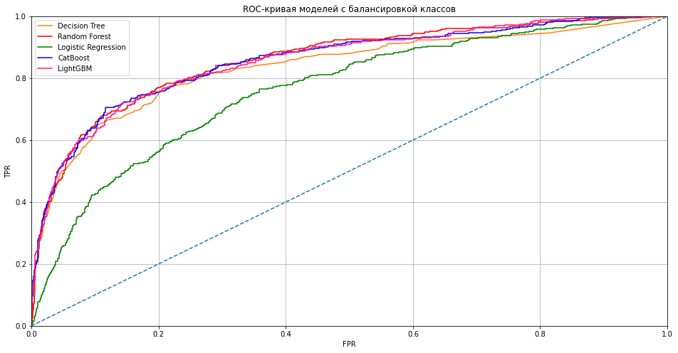

```python
# Строим графики ROC-кривых
plt.figure(figsize=(16, 8))
plt.xlim(0, 1)
plt.ylim(0, 1)
plt.title('ROC-кривая моделей с балансировкой классов')
plt.xlabel('FPR')
plt.ylabel('TPR')
plt.grid()
plt.plot([0, 1], [0, 1], linestyle='--')
fpr, tpr, thresholds = roc_curve(target_valid, predicted_prob_tree_w)
plt.plot(fpr, tpr, label='Decision Tree')
fpr, tpr, thresholds = roc_curve(target_valid, predicted_prob_forest_w)
plt.plot(fpr, tpr, color='red', label='Random Forest')
fpr, tpr, thresholds = roc_curve(target_valid, predicted_prob_logistic_w)
plt.plot(fpr, tpr, color='green', label='Logistic Regression')
fpr, tpr, thresholds = roc_curve(target_valid, predicted_prob_catb_w)
plt.plot(fpr, tpr, color='blue', label='CatBoost')
fpr, tpr, thresholds = roc_curve(target_valid, predicted_prob_lgbm_w)
plt.plot(fpr, tpr, color='deeppink', label='LightGBM')
plt.legend()
plt.show()
```

#### Выводы по результатам взвешивания

Основные параметры с сортировкой по убыванию F1-меры

```python
display(sum_result.sort_values('F1', ascending=False).style.format('{:.5f}'))
```

| variant_of_model | Accuracy | Recall | Precision | F1 |
| --- | --- | --- | --- | --- |
| CatBoost_w_balance | 0.84750 | 0.70516 | 0.60805 | 0.65301 |
| RandomForest_w_balance | 0.85950 | 0.61671 | 0.66755 | 0.64112 |
| LightGBM_w_balance | 0.83850 | 0.66585 | 0.59170 | 0.62659 |
| CatBoost_clear | 0.87050 | 0.49140 | 0.79365 | 0.60698 |
| RandomForest_clear | 0.86600 | 0.48649 | 0.77043 | 0.59639 |
| Tree_w_balance | 0.78800 | 0.76658 | 0.48674 | 0.59542 |
| LightGBM_clear | 0.86650 | 0.47666 | 0.78226 | 0.59237 |
| Tree_clear | 0.85000 | 0.51106 | 0.67314 | 0.58101 |
| LogisticRegression_w_balance | 0.70750 | 0.66339 | 0.37604 | 0.48000 |
| LogisticRegression_clear | 0.80950 | 0.21867 | 0.58553 | 0.31843 |

Нам удалось значительно улучшить показатели F1-меры для всех моделей. Особенно сильно выросло качество у Логистической регресии. При этом у всех моделей упали показатели Accuracy.

Если смотреть показатель AUC-ROC - картина не везде одинаковая:

### Upsampling

Создадим функцию для увлеичения представленности редкого класса:

```python
'''
    Функция для увелицения представленности редкого класса (у нас - это '1')

    features - фичи, по которым увеличиваем представленность класса
    target - таргеты, по которым увеличиваем представленность класса
    rank - число, во сколько раз увеличиваем

'''

def upsampler (features, target, rank):
    # отбираем классы
    features_zeros = features.loc[target_train == 0]
    features_ones = features.loc[target_train == 1]
    target_zeros = target.loc[target_train == 0]
    target_ones = target.loc[target_train == 1]

    # увеличиваем редкий класс, перемешиваем
    features_up = pd.concat([features_zeros] + [features_ones] * rank)
    target_up = pd.concat([target_zeros] + [target_ones] * rank)
    features_up, target_up = shuffle(features_up, target_up, random_state=42)

    # визуализируем классы после обработки
    plt.title('Результат балансировки классов методом upsampling')
    plt.pie(target_up.value_counts(),
    labels=['0', '1'],
    autopct='%.1f%%')
    plt.show()

    # Считаем долю сетевых от общего числа
    print(color.BOLD + color. BLUE +
          'Доля отточных клиентов после upsampling ='
          + color.END +' {:.1%} '.format(target_up.mean()))

    # Возвращаем обработанные фичи и таргеты
    return features_up, target_up
```

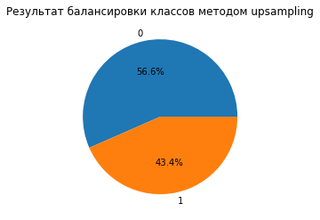

```
Доля отточных клиентов после upsampling = 43.4%
```

```python
# Балансируем классы с помощью функции
features_t_up, target_t_up = upsampler(features_train, target_train, 3)
```

Мы получили очень похожие доли класссов целевого признака. Попробуем обучить модели на этих данных.

#### Descision Tree

```python
tree_up = None
best_f1_tree = 0
# Подбираем гиперпараметры в цикле, чтобы определить лучшие настройки модели
for depth in range(1, 21, 1):
    for spl in range(2, 41, 1):
        # инициализируем модель с параметром random_state=42. Параметр max_depth подбираем в цикле
        model = DecisionTreeClassifier(random_state=42,
                                       max_depth=depth,
                                       min_samples_leaf = 9,
                                       min_samples_split = spl
                                      )
        model.fit(features_t_up, target_t_up) # обучаем модель на тренировочной выборке
        predicted_valid = model.predict(features_valid) # получаем предсказания модели на валидационной выборке
        f1 = f1_score(target_valid, predicted_valid) # считаем f1-меру на валидационной выборке
        if f1 > best_f1_tree: # отбираем параметры модели с лучшим результатом f1-меры
            best_f1_tree = f1
            tree_up = model

predicted_tree_up = tree_up.predict(features_valid) # получаем предсказания лучшей модели на валидационной выборке
```

```python
# Добавляем результат в таблицу
tree_up_result = show_metric(predicted_tree_up, 'Tree_upsampled')
sum_result = pd.concat([sum_result, tree_up_result])
display(sum_result.style.format('{:.5f}'))
```

| variant_of_model | Accuracy | Recall | Precision | F1 |
| --- | --- | --- | --- | --- |
| Tree_clear | 0.85000 | 0.51106 | 0.67314 | 0.58101 |
| RandomForest_clear | 0.86600 | 0.48649 | 0.77043 | 0.59639 |
| LogisticRegression_clear | 0.80950 | 0.21867 | 0.58553 | 0.31843 |
| CatBoost_clear | 0.87050 | 0.49140 | 0.79365 | 0.60698 |
| LightGBM_clear | 0.86650 | 0.47666 | 0.78226 | 0.59237 |
| Tree_w_balance | 0.78800 | 0.76658 | 0.48674 | 0.59542 |
| RandomForest_w_balance | 0.85950 | 0.61671 | 0.66755 | 0.64112 |
| LogisticRegression_w_balance | 0.70750 | 0.66339 | 0.37604 | 0.48000 |
| CatBoost_w_balance | 0.84750 | 0.70516 | 0.60805 | 0.65301 |
| LightGBM_w_balance | 0.83850 | 0.66585 | 0.59170 | 0.62659 |
| Tree_upsampled | 0.81700 | 0.68305 | 0.53981 | 0.60304 |

#### Random Forest

```python
forest_up = None
best_f1_forest = 0
# Подбираем гиперпараметры в цикле, чтобы определить лучшие настройки модели
for est in range(41, 51, 1):
    for depth in range(10, 21, 1):
        model = RandomForestClassifier(random_state=42,
                                       max_depth=depth,
                                       n_estimators=est,
                                       min_samples_leaf = 1,
                                       min_samples_split = 2
                                      )
        model.fit(features_t_up, target_t_up) # обучаем модель на тренировочной выборке
        predicted_valid = model.predict(features_valid) # получаем предсказания модели на валидационной выборке
        f1 = f1_score(target_valid, predicted_valid) # считаем f1-меру на валидационной выборке
        if f1 > best_f1_forest: # отбираем параметры модели с лучшим результатом f1-меры
            best_f1_forest = f1
            forest_up = model

predicted_forest_up = forest_up.predict(features_valid) # получаем предсказания лучшей модели на валидационной выборке
```

```python
forest_up_result = show_metric(predicted_forest_up, 'RandomForest_upsampled')
sum_result = pd.concat([sum_result, forest_up_result])
display(sum_result.style.format('{:.5f}'))
```

| variant_of_model | Accuracy | Recall | Precision | F1 |
| --- | --- | --- | --- | --- |
| Tree_clear | 0.85000 | 0.51106 | 0.67314 | 0.58101 |
| RandomForest_clear | 0.86600 | 0.48649 | 0.77043 | 0.59639 |
| LogisticRegression_clear | 0.80950 | 0.21867 | 0.58553 | 0.31843 |
| CatBoost_clear | 0.87050 | 0.49140 | 0.79365 | 0.60698 |
| LightGBM_clear | 0.86650 | 0.47666 | 0.78226 | 0.59237 |
| Tree_w_balance | 0.78800 | 0.76658 | 0.48674 | 0.59542 |
| RandomForest_w_balance | 0.85950 | 0.61671 | 0.66755 | 0.64112 |
| LogisticRegression_w_balance | 0.70750 | 0.66339 | 0.37604 | 0.48000 |
| CatBoost_w_balance | 0.84750 | 0.70516 | 0.60805 | 0.65301 |
| LightGBM_w_balance | 0.83850 | 0.66585 | 0.59170 | 0.62659 |
| Tree_upsampled | 0.81700 | 0.68305 | 0.53981 | 0.60304 |
| RandomForest_upsampled | 0.85650 | 0.63882 | 0.65000 | 0.64436 |

#### Logistic Regression

```python
# Составляем массивы значений гиперпараметров
C = np.logspace(0, 10, num=20)
penalty = ['l1', 'l2']
solver = ['liblinear', 'saga']
# Составляем словарь гиперпараметров для GridSearchCV
hyperparameters = dict(C=C, penalty=penalty, solver=solver)

# Обучаем логистическую регрессию с помощью GridSearchCV
logistic_up = linear_model.LogisticRegression(random_state=42) # инициализируем модель
gridsearch = GridSearchCV(logistic_up, hyperparameters) # подбираем параметры
logistic_up = gridsearch.fit(features_t_up, target_t_up) # сохраняем лучшую модель

predicted_logistic_up = logistic_up.predict(features_valid) # получаем предсказания лучшей модели на валидационной выборке
```

```python
logistic_up_result = show_metric(predicted_logistic_up, 'LogisticRegression_upsampled')
sum_result = pd.concat([sum_result, logistic_up_result])
display(sum_result.style.format('{:.5f}'))
```

| variant_of_model | Accuracy | Recall | Precision | F1 |
| --- | --- | --- | --- | --- |
| Tree_clear | 0.85000 | 0.51106 | 0.67314 | 0.58101 |
| RandomForest_clear | 0.86600 | 0.48649 | 0.77043 | 0.59639 |
| LogisticRegression_clear | 0.80950 | 0.21867 | 0.58553 | 0.31843 |
| CatBoost_clear | 0.87050 | 0.49140 | 0.79365 | 0.60698 |
| LightGBM_clear | 0.86650 | 0.47666 | 0.78226 | 0.59237 |
| Tree_w_balance | 0.78800 | 0.76658 | 0.48674 | 0.59542 |
| RandomForest_w_balance | 0.85950 | 0.61671 | 0.66755 | 0.64112 |
| LogisticRegression_w_balance | 0.70750 | 0.66339 | 0.37604 | 0.48000 |
| CatBoost_w_balance | 0.84750 | 0.70516 | 0.60805 | 0.65301 |
| LightGBM_w_balance | 0.83850 | 0.66585 | 0.59170 | 0.62659 |
| Tree_upsampled | 0.81700 | 0.68305 | 0.53981 | 0.60304 |
| RandomForest_upsampled | 0.85650 | 0.63882 | 0.65000 | 0.64436 |
| LogisticRegression_upsampled | 0.75500 | 0.56511 | 0.42357 | 0.48421 |

#### CatBoost

```python
# инициализируем модель CatBoostClassifier
catb_up = CatBoostClassifier(
    leaf_estimation_method = 'Gradient',
    max_depth = 7,
    bootstrap_type = 'Bernoulli',
    objective = 'MultiClass',
    subsample = 0.8,
    random_state=42,
    iterations=1000,
    learning_rate=0.04,
    eval_metric='TotalF1',
    early_stopping_rounds = 100,
    verbose = 0
)

# обучаем модель
catb_up.fit(features_t_up, target_t_up, eval_set=(features_valid, target_valid))

predicted_catb_up = catb_up.predict(features_valid) # получаем предсказания модели на валидационной выборке
```

```python
catb_up_result = show_metric(predicted_catb_up, 'CatBoost_upsampled')
sum_result = pd.concat([sum_result, catb_up_result])
display(sum_result.style.format('{:.5f}'))
```

| variant_of_model | Accuracy | Recall | Precision | F1 |
| --- | --- | --- | --- | --- |
| Tree_clear | 0.85000 | 0.51106 | 0.67314 | 0.58101 |
| RandomForest_clear | 0.86600 | 0.48649 | 0.77043 | 0.59639 |
| LogisticRegression_clear | 0.80950 | 0.21867 | 0.58553 | 0.31843 |
| CatBoost_clear | 0.87050 | 0.49140 | 0.79365 | 0.60698 |
| LightGBM_clear | 0.86650 | 0.47666 | 0.78226 | 0.59237 |
| Tree_w_balance | 0.78800 | 0.76658 | 0.48674 | 0.59542 |
| RandomForest_w_balance | 0.85950 | 0.61671 | 0.66755 | 0.64112 |
| LogisticRegression_w_balance | 0.70750 | 0.66339 | 0.37604 | 0.48000 |
| CatBoost_w_balance | 0.84750 | 0.70516 | 0.60805 | 0.65301 |
| LightGBM_w_balance | 0.83850 | 0.66585 | 0.59170 | 0.62659 |
| Tree_upsampled | 0.81700 | 0.68305 | 0.53981 | 0.60304 |
| RandomForest_upsampled | 0.85650 | 0.63882 | 0.65000 | 0.64436 |
| LogisticRegression_upsampled | 0.75500 | 0.56511 | 0.42357 | 0.48421 |
| CatBoost_upsampled | 0.84850 | 0.69779 | 0.61207 | 0.65212 |

#### LightGBM

```python
lgbm_up = lgb.LGBMClassifier(objective="binary",
                          n_estimators=2000,
                          random_state=42,
                          learning_rate=0.05,
                          early_stopping_rounds = 1000,
                          verbose = -1
                         )

lgbm_up.fit(features_t_up, target_t_up, eval_set=[(features_valid, target_valid),])

predicted_lgbm_up = lgbm_up.predict(features_valid) # получаем предсказания модели на валидационной выборке
```

[output not shown]

[output cut: 1262 more lines]

[output not shown]

```python
lgbm_up_result = show_metric(predicted_lgbm_up, 'LightGBM_upsampled')
sum_result = pd.concat([sum_result, lgbm_up_result])
display(sum_result.style.format('{:.5f}'))
```

| variant_of_model | Accuracy | Recall | Precision | F1 |
| --- | --- | --- | --- | --- |
| Tree_clear | 0.85000 | 0.51106 | 0.67314 | 0.58101 |
| RandomForest_clear | 0.86600 | 0.48649 | 0.77043 | 0.59639 |
| LogisticRegression_clear | 0.80950 | 0.21867 | 0.58553 | 0.31843 |
| CatBoost_clear | 0.87050 | 0.49140 | 0.79365 | 0.60698 |
| LightGBM_clear | 0.86650 | 0.47666 | 0.78226 | 0.59237 |
| Tree_w_balance | 0.78800 | 0.76658 | 0.48674 | 0.59542 |
| RandomForest_w_balance | 0.85950 | 0.61671 | 0.66755 | 0.64112 |
| LogisticRegression_w_balance | 0.70750 | 0.66339 | 0.37604 | 0.48000 |
| CatBoost_w_balance | 0.84750 | 0.70516 | 0.60805 | 0.65301 |
| LightGBM_w_balance | 0.83850 | 0.66585 | 0.59170 | 0.62659 |
| Tree_upsampled | 0.81700 | 0.68305 | 0.53981 | 0.60304 |
| RandomForest_upsampled | 0.85650 | 0.63882 | 0.65000 | 0.64436 |
| LogisticRegression_upsampled | 0.75500 | 0.56511 | 0.42357 | 0.48421 |
| CatBoost_upsampled | 0.84850 | 0.69779 | 0.61207 | 0.65212 |
| LightGBM_upsampled | 0.85000 | 0.64128 | 0.62892 | 0.63504 |

#### ROC-кривая. AUC-ROC на upsampling

```python
# Считаем предсказания вероятностей для моделей
predicted_prob_tree_up = tree_up.predict_proba(features_valid)[:, 1]
predicted_prob_forest_up = forest_up.predict_proba(features_valid)[:, 1]
predicted_prob_logistic_up = logistic_up.predict_proba(features_valid)[:, 1]
predicted_prob_catb_up = catb_up.predict_proba(features_valid)[:, 1]
predicted_prob_lgbm_up = lgbm_up.predict_proba(features_valid)[:, 1]

# Выводим значения AUC_ROC
print('AUC_ROC DecisionTreeClassifier:', roc_auc_score(target_valid, predicted_prob_tree_up))
print('AUC_ROC RandomForestClassifier:', roc_auc_score(target_valid, predicted_prob_forest_up))
print('AUC_ROC LogisticRegression:', roc_auc_score(target_valid, predicted_prob_logistic_up))
print('AUC_ROC CatBoostClassifier:', roc_auc_score(target_valid, predicted_prob_catb_up))
print('AUC_ROC LGBMClassifier:', roc_auc_score(target_valid, predicted_prob_lgbm_up))
```

```
AUC_ROC DecisionTreeClassifier: 0.8406819762751966
AUC_ROC RandomForestClassifier: 0.8600048430556905
AUC_ROC LogisticRegression: 0.7597104037782004
AUC_ROC CatBoostClassifier: 0.8632839310805414
AUC_ROC LGBMClassifier: 0.8533047685590058
```

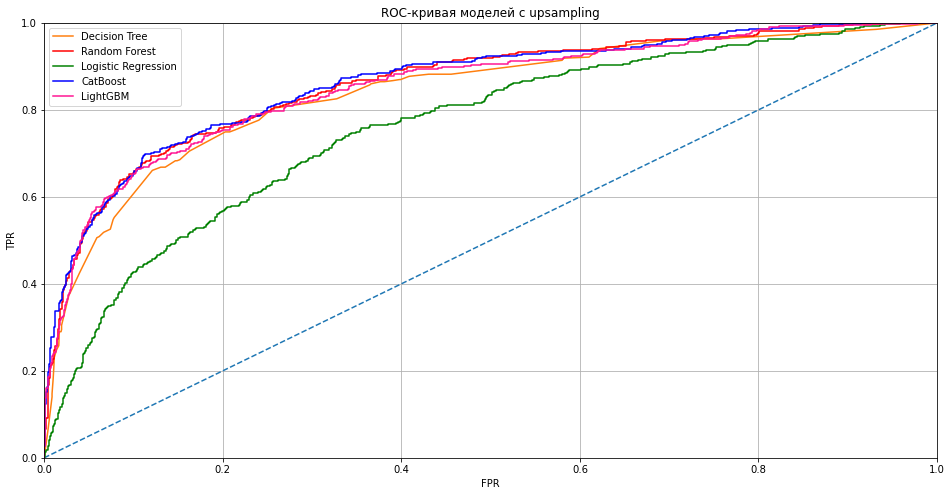

```python
# Строим графики ROC-кривых
plt.figure(figsize=(16, 8))
plt.xlim(0, 1)
plt.ylim(0, 1)
plt.title('ROC-кривая моделей с upsampling')
plt.xlabel('FPR')
plt.ylabel('TPR')
plt.grid()
plt.plot([0, 1], [0, 1], linestyle='--')
fpr, tpr, thresholds = roc_curve(target_valid, predicted_prob_tree_up)
plt.plot(fpr, tpr, label='Decision Tree')
fpr, tpr, thresholds = roc_curve(target_valid, predicted_prob_forest_up)
plt.plot(fpr, tpr, color='red', label='Random Forest')
fpr, tpr, thresholds = roc_curve(target_valid, predicted_prob_logistic_up)
plt.plot(fpr, tpr, color='green', label='Logistic Regression')
fpr, tpr, thresholds = roc_curve(target_valid, predicted_prob_catb_up)
plt.plot(fpr, tpr, color='blue', label='CatBoost')
fpr, tpr, thresholds = roc_curve(target_valid, predicted_prob_lgbm_up)
plt.plot(fpr, tpr, color='deeppink', label='LightGBM')
plt.legend()
plt.show()
```

#### Выводы по результатам взвешивания

Результаты AUC-ROC до взвешивания классов:

- AUC_ROC DecisionTreeClassifier: 0.8229701195802891
- AUC_ROC RandomForestClassifier: 0.8462553462553462
- AUC_ROC LogisticRegression: 0.7558467558467559
- AUC_ROC CatBoostClassifier: 0.8647692376505937
- AUC_ROC LGBMClassifier: 0.8646227120803391

Результаты AUC-ROC после взвешивания классов:

- AUC_ROC DecisionTreeClassifier: 0.8347546313648009
- AUC_ROC RandomForestClassifier: 0.8589514013242827
- AUC_ROC LogisticRegression: 0.7606065233183877
- AUC_ROC CatBoostClassifier: 0.8629615748259815
- AUC_ROC LGBMClassifier: 0.8552527874561774

Результаты AUC-ROC после upsampling:

- AUC_ROC DecisionTreeClassifier: 0.8406819762751966
- AUC_ROC RandomForestClassifier: 0.8600048430556905
- AUC_ROC LogisticRegression: 0.7597104037782004
- AUC_ROC CatBoostClassifier: 0.8632839310805414
- AUC_ROC LGBMClassifier: 0.8533047685590058

Результаты AUC-ROC после применения upsampling для DecisionTree и RandomForest получились лучше, чем при взвешивании классов. Для Логистической регрессии - чуть хуже взвешивания.

Наболее устойчивы в целом к дисбалансу классов модели градиентного бустинга - CatBoost и LightGBM.

Основные параметры с сортировкой по убыванию F1-меры

```python
display(sum_result.sort_values('F1', ascending=False).style.format('{:.5f}'))
```

| variant_of_model | Accuracy | Recall | Precision | F1 |
| --- | --- | --- | --- | --- |
| CatBoost_w_balance | 0.84750 | 0.70516 | 0.60805 | 0.65301 |
| CatBoost_upsampled | 0.84850 | 0.69779 | 0.61207 | 0.65212 |
| RandomForest_upsampled | 0.85650 | 0.63882 | 0.65000 | 0.64436 |
| RandomForest_w_balance | 0.85950 | 0.61671 | 0.66755 | 0.64112 |
| LightGBM_upsampled | 0.85000 | 0.64128 | 0.62892 | 0.63504 |
| LightGBM_w_balance | 0.83850 | 0.66585 | 0.59170 | 0.62659 |
| CatBoost_clear | 0.87050 | 0.49140 | 0.79365 | 0.60698 |
| Tree_upsampled | 0.81700 | 0.68305 | 0.53981 | 0.60304 |
| RandomForest_clear | 0.86600 | 0.48649 | 0.77043 | 0.59639 |
| Tree_w_balance | 0.78800 | 0.76658 | 0.48674 | 0.59542 |
| LightGBM_clear | 0.86650 | 0.47666 | 0.78226 | 0.59237 |
| Tree_clear | 0.85000 | 0.51106 | 0.67314 | 0.58101 |
| LogisticRegression_upsampled | 0.75500 | 0.56511 | 0.42357 | 0.48421 |
| LogisticRegression_w_balance | 0.70750 | 0.66339 | 0.37604 | 0.48000 |
| LogisticRegression_clear | 0.80950 | 0.21867 | 0.58553 | 0.31843 |

Как мы видим, лидерство по параметру F1-меры по-прежнему сохраняет CatBoost. Хорошо себя показал RandomForest. Его показатели с upsampling даж лучше - 3-е место.

### Downsampling

Создадим функцию для уменьшения представленности частого класса:

```python
'''
    Функция для уменьшения представленности доминирующего класса (у нас - это '0')

    features - фичи, по которым уменьшаем представленность класса
    target - таргеты, по которым уменьшаем представленность класса
    frac - доля снижения представленности класса

'''

def downsampler(features, target, frac):
    # отбираем классы
    features_zeros = features.loc[target_train == 0]
    features_ones = features.loc[target_train == 1]
    target_zeros = target.loc[target_train == 0]
    target_ones = target.loc[target_train == 1]

    # урезаем доминирующий класс, перемешиваем
    features_dwn = pd.concat([features_zeros.sample(frac=frac, random_state=42)] + [features_ones])
    target_dwn = pd.concat([target_zeros.sample(frac=frac, random_state=42)] + [target_ones])
    features_dwn, target_dwn = shuffle(features_dwn, target_dwn, random_state=42)

    # визуализируем классы после обработки
    plt.title('Результат балансировки классов методом upsampling')
    plt.pie(target_dwn.value_counts(),
    labels=['0', '1'],
    autopct='%.1f%%')
    plt.show()

    # Считаем долю сетевых от общего числа
    print(color.BOLD + color. BLUE +
          'Доля отточных клиентов после downsampling ='
          + color.END +' {:.1%} '.format(target_dwn.mean()))

    # Возвращаем обработанные фичи и таргеты
    return features_dwn, target_dwn
```

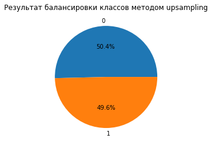

```
Доля отточных клиентов после downsampling = 49.6%
```

```python
# Балансируем классы с помощью функции
features_t_dwn, target_t_dwn = downsampler(features_train, target_train, 0.26)
```

Мы получили почти равные доли классов. Попробуем обучить модели на новых данных.

#### Descision Tree

```python
tree_dwn = None
best_f1_tree = 0
# Подбираем гиперпараметры в цикле, чтобы определить лучшие настройки модели
for depth in range(1, 21, 1):
    for spl in range(2, 41, 1):
        # инициализируем модель с параметром random_state=42. Параметр max_depth подбираем в цикле
        model = DecisionTreeClassifier(random_state=42,
                                       max_depth=depth,
                                       min_samples_leaf = 9,
                                       min_samples_split = spl
                                      )
        model.fit(features_t_dwn, target_t_dwn) # обучаем модель на тренировочной выборке
        predicted_valid = model.predict(features_valid) # получаем предсказания модели на валидационной выборке
        f1 = f1_score(target_valid, predicted_valid) # считаем f1-меру на валидационной выборке
        if f1 > best_f1_tree: # отбираем параметры модели с лучшим результатом f1-меры
            best_f1_tree = f1
            tree_dwn = model

predicted_tree_dwn = tree_dwn.predict(features_valid) # получаем предсказания лучшей модели на валидационной выборке
```

```python
# Добавляем результат в таблицу
tree_dwn_result = show_metric(predicted_tree_dwn, 'Tree_downsampled')
sum_result = pd.concat([sum_result, tree_dwn_result])
display(sum_result.style.format('{:.5f}'))
```

| variant_of_model | Accuracy | Recall | Precision | F1 |
| --- | --- | --- | --- | --- |
| Tree_clear | 0.85000 | 0.51106 | 0.67314 | 0.58101 |
| RandomForest_clear | 0.86600 | 0.48649 | 0.77043 | 0.59639 |
| LogisticRegression_clear | 0.80950 | 0.21867 | 0.58553 | 0.31843 |
| CatBoost_clear | 0.87050 | 0.49140 | 0.79365 | 0.60698 |
| LightGBM_clear | 0.86650 | 0.47666 | 0.78226 | 0.59237 |
| Tree_w_balance | 0.78800 | 0.76658 | 0.48674 | 0.59542 |
| RandomForest_w_balance | 0.85950 | 0.61671 | 0.66755 | 0.64112 |
| LogisticRegression_w_balance | 0.70750 | 0.66339 | 0.37604 | 0.48000 |
| CatBoost_w_balance | 0.84750 | 0.70516 | 0.60805 | 0.65301 |
| LightGBM_w_balance | 0.83850 | 0.66585 | 0.59170 | 0.62659 |
| Tree_upsampled | 0.81700 | 0.68305 | 0.53981 | 0.60304 |
| RandomForest_upsampled | 0.85650 | 0.63882 | 0.65000 | 0.64436 |
| LogisticRegression_upsampled | 0.75500 | 0.56511 | 0.42357 | 0.48421 |
| CatBoost_upsampled | 0.84850 | 0.69779 | 0.61207 | 0.65212 |
| LightGBM_upsampled | 0.85000 | 0.64128 | 0.62892 | 0.63504 |
| Tree_downsampled | 0.80050 | 0.73710 | 0.50676 | 0.60060 |

#### Random Forest

```python
forest_dwn = None
best_f1_forest = 0
# Подбираем гиперпараметры в цикле, чтобы определить лучшие настройки модели
for est in range(41, 51, 1):
    for depth in range(10, 21, 1):
        model = RandomForestClassifier(random_state=42,
                                       max_depth=depth,
                                       n_estimators=est,
                                       min_samples_leaf = 1,
                                       min_samples_split = 2
                                      )
        model.fit(features_t_dwn, target_t_dwn) # обучаем модель на тренировочной выборке
        predicted_valid = model.predict(features_valid) # получаем предсказания модели на валидационной выборке
        f1 = f1_score(target_valid, predicted_valid) # считаем f1-меру на валидационной выборке
        if f1 > best_f1_forest: # отбираем параметры модели с лучшим результатом f1-меры
            best_f1_forest = f1
            forest_dwn = model

predicted_forest_dwn = forest_dwn.predict(features_valid) # получаем предсказания лучшей модели на валидационной выборке
```

```python
forest_dwn_result = show_metric(predicted_forest_dwn, 'RandomForest_downsampled')
sum_result = pd.concat([sum_result, forest_dwn_result])
display(sum_result.style.format('{:.5f}'))
```

| variant_of_model | Accuracy | Recall | Precision | F1 |
| --- | --- | --- | --- | --- |
| Tree_clear | 0.85000 | 0.51106 | 0.67314 | 0.58101 |
| RandomForest_clear | 0.86600 | 0.48649 | 0.77043 | 0.59639 |
| LogisticRegression_clear | 0.80950 | 0.21867 | 0.58553 | 0.31843 |
| CatBoost_clear | 0.87050 | 0.49140 | 0.79365 | 0.60698 |
| LightGBM_clear | 0.86650 | 0.47666 | 0.78226 | 0.59237 |
| Tree_w_balance | 0.78800 | 0.76658 | 0.48674 | 0.59542 |
| RandomForest_w_balance | 0.85950 | 0.61671 | 0.66755 | 0.64112 |
| LogisticRegression_w_balance | 0.70750 | 0.66339 | 0.37604 | 0.48000 |
| CatBoost_w_balance | 0.84750 | 0.70516 | 0.60805 | 0.65301 |
| LightGBM_w_balance | 0.83850 | 0.66585 | 0.59170 | 0.62659 |
| Tree_upsampled | 0.81700 | 0.68305 | 0.53981 | 0.60304 |
| RandomForest_upsampled | 0.85650 | 0.63882 | 0.65000 | 0.64436 |
| LogisticRegression_upsampled | 0.75500 | 0.56511 | 0.42357 | 0.48421 |
| CatBoost_upsampled | 0.84850 | 0.69779 | 0.61207 | 0.65212 |
| LightGBM_upsampled | 0.85000 | 0.64128 | 0.62892 | 0.63504 |
| Tree_downsampled | 0.80050 | 0.73710 | 0.50676 | 0.60060 |
| RandomForest_downsampled | 0.80250 | 0.77150 | 0.50974 | 0.61388 |

#### Logistic Regression

```python
# Составляем массивы значений гиперпараметров
C = np.logspace(0, 10, num=20)
penalty = ['l1', 'l2']
solver = ['liblinear', 'saga']
# Составляем словарь гиперпараметров для GridSearchCV
hyperparameters = dict(C=C, penalty=penalty, solver=solver)

# Обучаем логистическую регрессию с помощью GridSearchCV
logistic_dwn = linear_model.LogisticRegression(random_state=42) # инициализируем модель
gridsearch = GridSearchCV(logistic_dwn, hyperparameters) # подбираем параметры
logistic_dwn = gridsearch.fit(features_t_dwn, target_t_dwn) # сохраняем лучшую модель

predicted_logistic_dwn = logistic_dwn.predict(features_valid) # получаем предсказания лучшей модели на валидационной выборке
```

```python
logistic_dwn_result = show_metric(predicted_logistic_dwn, 'LogisticRegression_downsampled')
sum_result = pd.concat([sum_result, logistic_dwn_result])
display(sum_result.style.format('{:.5f}'))
```

| variant_of_model | Accuracy | Recall | Precision | F1 |
| --- | --- | --- | --- | --- |
| Tree_clear | 0.85000 | 0.51106 | 0.67314 | 0.58101 |
| RandomForest_clear | 0.86600 | 0.48649 | 0.77043 | 0.59639 |
| LogisticRegression_clear | 0.80950 | 0.21867 | 0.58553 | 0.31843 |
| CatBoost_clear | 0.87050 | 0.49140 | 0.79365 | 0.60698 |
| LightGBM_clear | 0.86650 | 0.47666 | 0.78226 | 0.59237 |
| Tree_w_balance | 0.78800 | 0.76658 | 0.48674 | 0.59542 |
| RandomForest_w_balance | 0.85950 | 0.61671 | 0.66755 | 0.64112 |
| LogisticRegression_w_balance | 0.70750 | 0.66339 | 0.37604 | 0.48000 |
| CatBoost_w_balance | 0.84750 | 0.70516 | 0.60805 | 0.65301 |
| LightGBM_w_balance | 0.83850 | 0.66585 | 0.59170 | 0.62659 |
| Tree_upsampled | 0.81700 | 0.68305 | 0.53981 | 0.60304 |
| RandomForest_upsampled | 0.85650 | 0.63882 | 0.65000 | 0.64436 |
| LogisticRegression_upsampled | 0.75500 | 0.56511 | 0.42357 | 0.48421 |
| CatBoost_upsampled | 0.84850 | 0.69779 | 0.61207 | 0.65212 |
| LightGBM_upsampled | 0.85000 | 0.64128 | 0.62892 | 0.63504 |
| Tree_downsampled | 0.80050 | 0.73710 | 0.50676 | 0.60060 |
| RandomForest_downsampled | 0.80250 | 0.77150 | 0.50974 | 0.61388 |
| LogisticRegression_downsampled | 0.71250 | 0.65356 | 0.38000 | 0.48058 |

#### CatBoost

```python
# инициализируем модель CatBoostClassifier
catb_dwn = CatBoostClassifier(
    leaf_estimation_method = 'Gradient',
    max_depth = 7,
    bootstrap_type = 'Bernoulli',
    objective = 'MultiClass',
    subsample = 0.8,
    random_state=42,
    iterations=1000,
    learning_rate=0.04,
    eval_metric='TotalF1',
    early_stopping_rounds = 100,
    verbose = 0
)

# обучаем модель
catb_dwn.fit(features_t_dwn, target_t_dwn, eval_set=(features_valid, target_valid))

predicted_catb_dwn = catb_dwn.predict(features_valid) # получаем предсказания модели на валидационной выборке
```

```python
catb_dwn_result = show_metric(predicted_catb_dwn, 'CatBoost_downsampled')
sum_result = pd.concat([sum_result, catb_dwn_result])
display(sum_result.style.format('{:.5f}'))
```

| variant_of_model | Accuracy | Recall | Precision | F1 |
| --- | --- | --- | --- | --- |
| Tree_clear | 0.85000 | 0.51106 | 0.67314 | 0.58101 |
| RandomForest_clear | 0.86600 | 0.48649 | 0.77043 | 0.59639 |
| LogisticRegression_clear | 0.80950 | 0.21867 | 0.58553 | 0.31843 |
| CatBoost_clear | 0.87050 | 0.49140 | 0.79365 | 0.60698 |
| LightGBM_clear | 0.86650 | 0.47666 | 0.78226 | 0.59237 |
| Tree_w_balance | 0.78800 | 0.76658 | 0.48674 | 0.59542 |
| RandomForest_w_balance | 0.85950 | 0.61671 | 0.66755 | 0.64112 |
| LogisticRegression_w_balance | 0.70750 | 0.66339 | 0.37604 | 0.48000 |
| CatBoost_w_balance | 0.84750 | 0.70516 | 0.60805 | 0.65301 |
| LightGBM_w_balance | 0.83850 | 0.66585 | 0.59170 | 0.62659 |
| Tree_upsampled | 0.81700 | 0.68305 | 0.53981 | 0.60304 |
| RandomForest_upsampled | 0.85650 | 0.63882 | 0.65000 | 0.64436 |
| LogisticRegression_upsampled | 0.75500 | 0.56511 | 0.42357 | 0.48421 |
| CatBoost_upsampled | 0.84850 | 0.69779 | 0.61207 | 0.65212 |
| LightGBM_upsampled | 0.85000 | 0.64128 | 0.62892 | 0.63504 |
| Tree_downsampled | 0.80050 | 0.73710 | 0.50676 | 0.60060 |
| RandomForest_downsampled | 0.80250 | 0.77150 | 0.50974 | 0.61388 |
| LogisticRegression_downsampled | 0.71250 | 0.65356 | 0.38000 | 0.48058 |
| CatBoost_downsampled | 0.79950 | 0.75921 | 0.50490 | 0.60648 |

#### LightGBM

```python
lgbm_dwn = lgb.LGBMClassifier(objective="binary",
                          n_estimators=2000,
                          random_state=42,
                          learning_rate=0.05,
                          early_stopping_rounds = 1000,
                          verbose = -1
                         )

lgbm_dwn.fit(features_t_dwn, target_t_dwn, eval_set=[(features_valid, target_valid),])

predicted_lgbm_dwn = lgbm_dwn.predict(features_valid) # получаем предсказания модели на валидационной выборке
```

[output not shown]

[output cut: 1034 more lines]

[output not shown]

```python
lgbm_dwn_result = show_metric(predicted_lgbm_dwn, 'LightGBM_downsampled')
sum_result = pd.concat([sum_result, lgbm_dwn_result])
display(sum_result.style.format('{:.5f}'))
```

| variant_of_model | Accuracy | Recall | Precision | F1 |
| --- | --- | --- | --- | --- |
| Tree_clear | 0.85000 | 0.51106 | 0.67314 | 0.58101 |
| RandomForest_clear | 0.86600 | 0.48649 | 0.77043 | 0.59639 |
| LogisticRegression_clear | 0.80950 | 0.21867 | 0.58553 | 0.31843 |
| CatBoost_clear | 0.87050 | 0.49140 | 0.79365 | 0.60698 |
| LightGBM_clear | 0.86650 | 0.47666 | 0.78226 | 0.59237 |
| Tree_w_balance | 0.78800 | 0.76658 | 0.48674 | 0.59542 |
| RandomForest_w_balance | 0.85950 | 0.61671 | 0.66755 | 0.64112 |
| LogisticRegression_w_balance | 0.70750 | 0.66339 | 0.37604 | 0.48000 |
| CatBoost_w_balance | 0.84750 | 0.70516 | 0.60805 | 0.65301 |
| LightGBM_w_balance | 0.83850 | 0.66585 | 0.59170 | 0.62659 |
| Tree_upsampled | 0.81700 | 0.68305 | 0.53981 | 0.60304 |
| RandomForest_upsampled | 0.85650 | 0.63882 | 0.65000 | 0.64436 |
| LogisticRegression_upsampled | 0.75500 | 0.56511 | 0.42357 | 0.48421 |
| CatBoost_upsampled | 0.84850 | 0.69779 | 0.61207 | 0.65212 |
| LightGBM_upsampled | 0.85000 | 0.64128 | 0.62892 | 0.63504 |
| Tree_downsampled | 0.80050 | 0.73710 | 0.50676 | 0.60060 |
| RandomForest_downsampled | 0.80250 | 0.77150 | 0.50974 | 0.61388 |
| LogisticRegression_downsampled | 0.71250 | 0.65356 | 0.38000 | 0.48058 |
| CatBoost_downsampled | 0.79950 | 0.75921 | 0.50490 | 0.60648 |
| LightGBM_downsampled | 0.79450 | 0.76167 | 0.49679 | 0.60136 |

#### ROC-кривая. AUC-ROC на downsampling

```python
# Считаем предсказания вероятностей для моделей
predicted_prob_tree_dwn = tree_dwn.predict_proba(features_valid)[:, 1]
predicted_prob_forest_dwn = forest_dwn.predict_proba(features_valid)[:, 1]
predicted_prob_logistic_dwn = logistic_dwn.predict_proba(features_valid)[:, 1]
predicted_prob_catb_dwn = catb_dwn.predict_proba(features_valid)[:, 1]
predicted_prob_lgbm_dwn = lgbm_dwn.predict_proba(features_valid)[:, 1]

# Выводим значения AUC_ROC
print('AUC_ROC DecisionTreeClassifier:', roc_auc_score(target_valid, predicted_prob_tree_dwn))
print('AUC_ROC RandomForestClassifier:', roc_auc_score(target_valid, predicted_prob_forest_dwn))
print('AUC_ROC LogisticRegression:', roc_auc_score(target_valid, predicted_prob_logistic_dwn))
print('AUC_ROC CatBoostClassifier:', roc_auc_score(target_valid, predicted_prob_catb_dwn))
print('AUC_ROC LGBMClassifier:', roc_auc_score(target_valid, predicted_prob_lgbm_dwn))
```

```
AUC_ROC DecisionTreeClassifier: 0.8244770193922737
AUC_ROC RandomForestClassifier: 0.8557540591438896
AUC_ROC LogisticRegression: 0.7592384372045389
AUC_ROC CatBoostClassifier: 0.8585904857091298
AUC_ROC LGBMClassifier: 0.8592976643824102
```

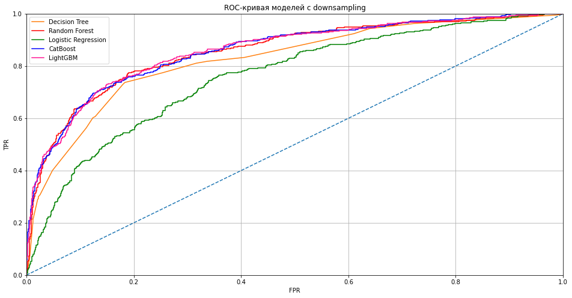

```python
# Строим графики ROC-кривых
plt.figure(figsize=(16, 8))
plt.xlim(0, 1)
plt.ylim(0, 1)
plt.title('ROC-кривая моделей с downsampling')
plt.xlabel('FPR')
plt.ylabel('TPR')
plt.grid()
plt.plot([0, 1], [0, 1], linestyle='--')
fpr, tpr, thresholds = roc_curve(target_valid, predicted_prob_tree_dwn)
plt.plot(fpr, tpr, label='Decision Tree')
fpr, tpr, thresholds = roc_curve(target_valid, predicted_prob_forest_dwn)
plt.plot(fpr, tpr, color='red', label='Random Forest')
fpr, tpr, thresholds = roc_curve(target_valid, predicted_prob_logistic_dwn)
plt.plot(fpr, tpr, color='green', label='Logistic Regression')
fpr, tpr, thresholds = roc_curve(target_valid, predicted_prob_catb_dwn)
plt.plot(fpr, tpr, color='blue', label='CatBoost')
fpr, tpr, thresholds = roc_curve(target_valid, predicted_prob_lgbm_dwn)
plt.plot(fpr, tpr, color='deeppink', label='LightGBM')
plt.legend()
plt.show()
```

#### Выводы по результатам downsampling

Результаты AUC-ROC до взвешивания классов:

- AUC_ROC DecisionTreeClassifier: 0.8229701195802891
- AUC_ROC RandomForestClassifier: 0.8462553462553462
- AUC_ROC LogisticRegression: 0.7558467558467559
- AUC_ROC CatBoostClassifier: 0.8647692376505937
- AUC_ROC LGBMClassifier: 0.8646227120803391

Результаты AUC-ROC после взвешивания классов:

- AUC_ROC DecisionTreeClassifier: 0.8347546313648009
- AUC_ROC RandomForestClassifier: 0.8589514013242827
- AUC_ROC LogisticRegression: 0.7606065233183877
- AUC_ROC CatBoostClassifier: 0.8629615748259815
- AUC_ROC LGBMClassifier: 0.8552527874561774

Результаты AUC-ROC после upsampling:

- AUC_ROC DecisionTreeClassifier: 0.8406819762751966
- AUC_ROC RandomForestClassifier: 0.8600048430556905
- AUC_ROC LogisticRegression: 0.7597104037782004
- AUC_ROC CatBoostClassifier: 0.8632839310805414
- AUC_ROC LGBMClassifier: 0.8533047685590058

Результаты AUC-ROC после downsampling:

- AUC_ROC DecisionTreeClassifier: 0.8244770193922737
- AUC_ROC RandomForestClassifier: 0.8557540591438896
- AUC_ROC LogisticRegression: 0.7592384372045389
- AUC_ROC CatBoostClassifier: 0.8585904857091298
- AUC_ROC LGBMClassifier: 0.8592976643824102

Downsampling показал результаты ожидаемо хуже, чем upsampling. Данных для обучения у нас и так немного, а в случае downsampling мы сделали их еще меньше.

```python
display(sum_result.sort_values('F1', ascending=False).style.format('{:.5f}'))
```

| variant_of_model | Accuracy | Recall | Precision | F1 |
| --- | --- | --- | --- | --- |
| CatBoost_w_balance | 0.84750 | 0.70516 | 0.60805 | 0.65301 |
| CatBoost_upsampled | 0.84850 | 0.69779 | 0.61207 | 0.65212 |
| RandomForest_upsampled | 0.85650 | 0.63882 | 0.65000 | 0.64436 |
| RandomForest_w_balance | 0.85950 | 0.61671 | 0.66755 | 0.64112 |
| LightGBM_upsampled | 0.85000 | 0.64128 | 0.62892 | 0.63504 |
| LightGBM_w_balance | 0.83850 | 0.66585 | 0.59170 | 0.62659 |
| RandomForest_downsampled | 0.80250 | 0.77150 | 0.50974 | 0.61388 |
| CatBoost_clear | 0.87050 | 0.49140 | 0.79365 | 0.60698 |
| CatBoost_downsampled | 0.79950 | 0.75921 | 0.50490 | 0.60648 |
| Tree_upsampled | 0.81700 | 0.68305 | 0.53981 | 0.60304 |
| LightGBM_downsampled | 0.79450 | 0.76167 | 0.49679 | 0.60136 |
| Tree_downsampled | 0.80050 | 0.73710 | 0.50676 | 0.60060 |
| RandomForest_clear | 0.86600 | 0.48649 | 0.77043 | 0.59639 |
| Tree_w_balance | 0.78800 | 0.76658 | 0.48674 | 0.59542 |
| LightGBM_clear | 0.86650 | 0.47666 | 0.78226 | 0.59237 |
| Tree_clear | 0.85000 | 0.51106 | 0.67314 | 0.58101 |
| LogisticRegression_upsampled | 0.75500 | 0.56511 | 0.42357 | 0.48421 |
| LogisticRegression_downsampled | 0.71250 | 0.65356 | 0.38000 | 0.48058 |
| LogisticRegression_w_balance | 0.70750 | 0.66339 | 0.37604 | 0.48000 |
| LogisticRegression_clear | 0.80950 | 0.21867 | 0.58553 | 0.31843 |

Ожидаемо - CatBoost остается лидером качества обученной модели.

### Выводы этапа

Результаты исследования реакции моделей на дисбаланс классов следующие:

- Наиболее устойчивыми к дисбалансу классов является модели градиентного бустинга - CatBoost и LightGBM, если судить по показателю AUC-ROC.
- Если принимать во внимание показатель F1-меры, то лучшая устойчивость к дисбалансу классов все же у CatBoost. Показатель F1 для LightGBM без обработки дисбаланса - ближе к концу списка (даже уступает RandomForest).
- Среди методов борьбы с дисбалансом классов лучше всего себя показали методы взвешивания классов и upsampling.
- Downsampling показал результаты ожидаемо хуже, чем upsampling. Данных для обучения у нас и так немного, а в случае downsampling мы сделали их еще меньше.

Абсолютным лидером среди исследованных моделей является CatBoost. Именно с этой моделью нам удалось добиться максимальных показателей F1-меры. Лучшие показатели получились с взвешенными классами. Лучших показателей Accuraсy score нам удалось достичь так же с моделью CatBoost, но без обработки дисбаланса классов.

Метрика F1 уравновешивает точность и полноту в положительном классе. Accuraсy показывает процент правильных ответов. Это имеет большое значение, особенно для несбалансированных задач. F1 учитывает правильно классифицированные наблюдения, как положительные, так и отрицательные.

Наша бизнес-задача - предсказывать клиентов, которые собираются покинуть банк. Предсказания будут вероятно использоваться для работы по стимулированию и повышению лояльности отточных клиентов. Данные показывают, что некоторый рост F1-меры при балансировке классов достигается за счет снижения точности и улучнения полноты (охвата). Обученный на несбалансированных данных CatBoost показывает хорошие результаты по F1 и при этом максимальный Accuracy с самым высоким Precision.

Нам интереснее вкладывать средства в удержание конкретно отточных клиентов. Именно по этим причинам мы отдаем прдпочтение модели CatBoost, обученной на данных без учета балансировки классов.

```python
display(sum_result.sort_values('F1', ascending=False).style.format('{:.5f}'))
```

| variant_of_model | Accuracy | Recall | Precision | F1 |
| --- | --- | --- | --- | --- |
| CatBoost_w_balance | 0.84750 | 0.70516 | 0.60805 | 0.65301 |
| CatBoost_upsampled | 0.84850 | 0.69779 | 0.61207 | 0.65212 |
| RandomForest_upsampled | 0.85650 | 0.63882 | 0.65000 | 0.64436 |
| RandomForest_w_balance | 0.85950 | 0.61671 | 0.66755 | 0.64112 |
| LightGBM_upsampled | 0.85000 | 0.64128 | 0.62892 | 0.63504 |
| LightGBM_w_balance | 0.83850 | 0.66585 | 0.59170 | 0.62659 |
| RandomForest_downsampled | 0.80250 | 0.77150 | 0.50974 | 0.61388 |
| CatBoost_clear | 0.87050 | 0.49140 | 0.79365 | 0.60698 |
| CatBoost_downsampled | 0.79950 | 0.75921 | 0.50490 | 0.60648 |
| Tree_upsampled | 0.81700 | 0.68305 | 0.53981 | 0.60304 |
| LightGBM_downsampled | 0.79450 | 0.76167 | 0.49679 | 0.60136 |
| Tree_downsampled | 0.80050 | 0.73710 | 0.50676 | 0.60060 |
| RandomForest_clear | 0.86600 | 0.48649 | 0.77043 | 0.59639 |
| Tree_w_balance | 0.78800 | 0.76658 | 0.48674 | 0.59542 |
| LightGBM_clear | 0.86650 | 0.47666 | 0.78226 | 0.59237 |
| Tree_clear | 0.85000 | 0.51106 | 0.67314 | 0.58101 |
| LogisticRegression_upsampled | 0.75500 | 0.56511 | 0.42357 | 0.48421 |
| LogisticRegression_downsampled | 0.71250 | 0.65356 | 0.38000 | 0.48058 |
| LogisticRegression_w_balance | 0.70750 | 0.66339 | 0.37604 | 0.48000 |
| LogisticRegression_clear | 0.80950 | 0.21867 | 0.58553 | 0.31843 |

```python
# Берем лучшую из моделей CatBoost без балансировки
catb = CatBoostClassifier(
    leaf_estimation_method = 'Gradient',
    max_depth = 8,
    bootstrap_type = 'Bernoulli',
    objective = 'MultiClass',
    subsample = 0.9,
    random_state=42,
    iterations=1000,
    learning_rate=0.05,
    eval_metric='TotalF1',
    early_stopping_rounds = 100,
    verbose = 0
)

# обучаем модель
catb.fit(features_train, target_train, eval_set=(features_valid, target_valid))

# Предсказываем вероятности на валидации
predicted_prob_catb = forest.predict_proba(features_valid)[:, 1]
df_catb = pd.DataFrame({'target': target_valid, 'prob': predicted_prob_forest})
thrs = [0] + list(df_catb['prob'].unique())
display(df_catb.head())
```

|  | target | prob |
| --- | --- | --- |
| 6263 | 0 | 0.00 |
| 7644 | 0 | 0.05 |
| 429 | 1 | 0.51 |
| 647 | 0 | 0.19 |
| 8353 | 1 | 0.23 |

```python
best_f1 = 0
thr_best = 0
for thr in thrs:
    df_catb['predicted'] = (df_catb['prob'] > thr) * 1
    f1 = f1_score(target_valid, df_catb['predicted'])
    if f1 > best_f1:
        best_f1 = f1
        thr_best = thr
thr_best
```

```
0.3689922480620156
```

```python
df_catb['predicted'] = (df_catb['prob'] > thr_best ) * 1
print('Accuracy:', accuracy_score(target_valid, df_catb['predicted']))
print('Recall:', recall_score(target_valid, df_catb['predicted']))
print('Precision:',precision_score(target_valid, df_catb['predicted']))
print('F1:', f1_score(target_valid, df_catb['predicted']))
```

```
Accuracy: 0.855
Recall: 0.6093366093366094
Precision: 0.6543535620052771
F1: 0.6310432569974556
```

Мы получили неплохие, но не лучшие показатели F1 и Accuracy

## Тестирование модели

### Обучение на объединенной выборке train+valid

Мы выбрали финальную модель. Теперь валидационная выборка нам не нужна, а значит мы можем попробовать увеличить точность модели, обучив ее на полных данных (train + valid).

```python
# Объединяем выборки
target_full = pd.concat([target_train, target_valid])
features_full = pd.concat([features_train, features_valid])
# Проверяем корректность действий на примере features_full
print('Количество строк в features_train + features_valid =', len(features_train) + len(features_valid))
print('Количество строк в features_full =', len(features_full))
```

```
Количество строк в features_train + features_valid = 8000
Количество строк в features_full = 8000
```

```python
# инициализируем модель CatBoostClassifier
catb_f = CatBoostClassifier(
    leaf_estimation_method = 'Gradient',
    max_depth = 8,
    bootstrap_type = 'Bernoulli',
    objective = 'MultiClass',
    subsample = 0.8,
    random_state=42,
    iterations=1000,
    learning_rate=0.04,
    eval_metric='TotalF1',
    early_stopping_rounds = 100,
    verbose = 0
)

# обучаем модель
catb_f.fit(features_full, target_full, eval_set=(features_test, target_test))
```

```
<catboost.core.CatBoostClassifier at 0x299f9b6e4c0>
```

### Результаты на тестовой выборке

Смотрим результат:

Мы смогли немного улучшить Accuracy и при этом заметно подтянуть F1.

```python
predicted_catb_test = catb_f.predict(features_test) # получаем предсказания модели на валидационной выборке
predicted_prob_catb_test = catb_f.predict_proba(features_test)[:, 1]

print('Accuracy:', accuracy_score(target_test, predicted_catb_test))
print('Recall:', recall_score(target_test, predicted_catb_test))
print('Precision:', precision_score(target_test, predicted_catb_test))
print('F1:', f1_score(target_test, predicted_catb_test))
print('AUC_ROC:', roc_auc_score(target_test, predicted_prob_catb_test))
```

```
Accuracy: 0.8765
Recall: 0.5012285012285013
Precision: 0.8225806451612904
F1: 0.6229007633587786
AUC_ROC: 0.8705438874930399
```

Построим ROC-кривую, чтобы визуализировать результат:

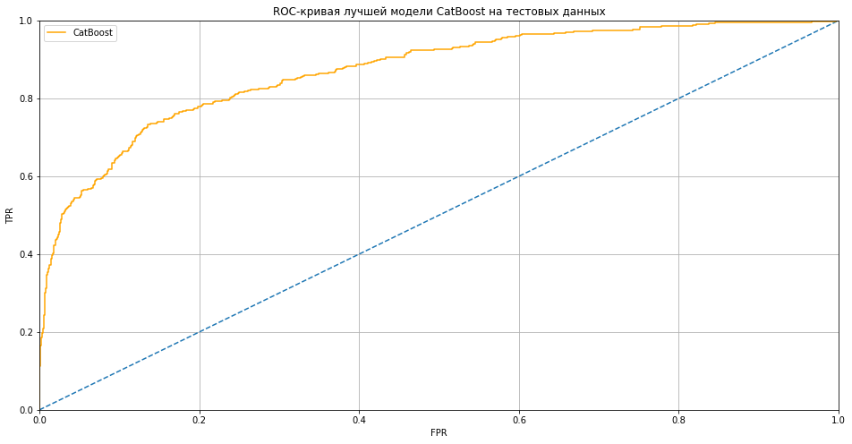

```python
# Строим графики ROC-кривых
plt.figure(figsize=(16, 8))
plt.xlim(0, 1)
plt.ylim(0, 1)
plt.title('ROC-кривая лучшей модели CatBoost на тестовых данных')
plt.xlabel('FPR')
plt.ylabel('TPR')
plt.grid()
plt.plot([0, 1], [0, 1], linestyle='--')
fpr, tpr, thresholds = roc_curve(target_test, predicted_prob_catb_test)
plt.plot(fpr, tpr, color='orange', label='CatBoost')
plt.legend()
plt.show()
```

### Выводы этапа

На тестовых данных модель CatBoost так же показывает стабильно высокие результаты:

- Accuracy: 0.8765
- Recall: 0.5012285012285013
- Precision: 0.8225806451612904
- F1: 0.6229007633587786
- AUC_ROC: 0.8705438874930399

Качество предсказаний модели так же удалось повысить за счет обучения на объединенной выборке train+valid.

## Выводы по проекту

**Предобработка данных**

- Имеющиеся данные высокого качества: нет дублей, явных выбросов и прочих проблем.
- Пропуски в поле `tenure` для 9% значений были заменены случайными значениями из набора имеющихся `tenure` с учетом весов. Случайное заполнение было выбрано, т.к. линейная и нелинейная корреляции `tenure` с целевым параметром и остальными практически отстуствует.
- Данные разделены на обучающую-валидационную-тестовую выборки в отношении 60%-20%-20% соответственно.
- Категориальные фичи были кодированы с помощью метода OHE с параметром drop_first = True.
- Исследование корреляции признаков показало:
  - между целевым параметром `exited` и признаками `age` и `num_of_products` достаточно высокая корреляция
  - между целевым параметром `exited` и признаками `gender`, `balance` и `is_active_member` средняя корреляция
  - после кодирования OHE в признаке `geography` нам удалось обнаружить средней силы связь по локации Германия и слабую нелинейную корреляцию по локации Испания.
  - по целевому признаку exited есть слабая положительная линейная корреляция по параметрам age и balance. Есть слабая отрицательная линейная корреляция по параметру is_active_member.
- Проведено масштабирование признаков с помощью метода 'StandardScaler'. Исходные фичи так жесохранены.

**Баланс классов.**

В имеющихся данных наблюдается дисбаланс классов: доля отточных клиентов в датасете = 20.4% (отточных клиентов в 4 раза меньше, чем актуальных).

**Исследование моделей**

Результаты исследования реакции моделей на дисбаланс классов следующие:

- Наиболее устойчивыми к дисбалансу классов является модели градиентного бустинга - CatBoost и LightGBM, если судить по показателю AUC-ROC.
- Если принимать во внимание показатель F1-меры, то лучшая устойчивость к дисбалансу классов все же у CatBoost. Показатель F1 для LightGBM без обработки дисбаланса - ближе к концу списка (даже уступает RandomForest).
- Среди методов борьбы с дисбалансом классов лучше всего себя показали методы взвешивания классов и upsampling.
- Downsampling показал результаты ожидаемо хуже, чем upsampling. Данных для обучения у нас и так немного, а в случае downsampling мы сделали их еще меньше.

Абсолютным лидером среди исследованных моделей является CatBoost. Именно с этой моделью нам удалось добиться максимальных показателей F1-меры. Лучшие показатели получились с взвешенными классами. Лучших показателей Accuraсy score нам удалось достичь так же с моделью CatBoost, но без обработки дисбаланса классов.

Метрика F1 уравновешивает точность и полноту в положительном классе. Accuraсy показывает процент правильных ответов. Это имеет большое значение, особенно для несбалансированных задач. F1 учитывает правильно классифицированные наблюдения, как положительные, так и отрицательные.

Наша бизнес-задача - предсказывать клиентов, которые собираются покинуть банк. Предсказания будут вероятно использоваться для работы по стимулированию и повышению лояльности отточных клиентов. Данные показывают, что некоторый рост F1-меры при балансировке классов достигается за счет снижения точности и улучнения полноты (охвата). Обученный на несбалансированных данных CatBoost показывает хорошие результаты по F1 и при этом максимальный Accuracy с самым высоким Precision.

Нам интереснее вкладывать средства в удержание конкретно отточных клиентов. Именно по этим причинам мы отдаем прдпочтение модели CatBoost, обученной на данных без учета балансировки классов.

```python
display(sum_result.sort_values('F1', ascending=False).style.format('{:.5f}'))
```

| variant_of_model | Accuracy | Recall | Precision | F1 |
| --- | --- | --- | --- | --- |
| CatBoost_w_balance | 0.84750 | 0.70516 | 0.60805 | 0.65301 |
| CatBoost_upsampled | 0.84850 | 0.69779 | 0.61207 | 0.65212 |
| RandomForest_upsampled | 0.85650 | 0.63882 | 0.65000 | 0.64436 |
| RandomForest_w_balance | 0.85950 | 0.61671 | 0.66755 | 0.64112 |
| LightGBM_upsampled | 0.85000 | 0.64128 | 0.62892 | 0.63504 |
| LightGBM_w_balance | 0.83850 | 0.66585 | 0.59170 | 0.62659 |
| RandomForest_downsampled | 0.80250 | 0.77150 | 0.50974 | 0.61388 |
| CatBoost_clear | 0.87050 | 0.49140 | 0.79365 | 0.60698 |
| CatBoost_downsampled | 0.79950 | 0.75921 | 0.50490 | 0.60648 |
| Tree_upsampled | 0.81700 | 0.68305 | 0.53981 | 0.60304 |
| LightGBM_downsampled | 0.79450 | 0.76167 | 0.49679 | 0.60136 |
| Tree_downsampled | 0.80050 | 0.73710 | 0.50676 | 0.60060 |
| RandomForest_clear | 0.86600 | 0.48649 | 0.77043 | 0.59639 |
| Tree_w_balance | 0.78800 | 0.76658 | 0.48674 | 0.59542 |
| LightGBM_clear | 0.86650 | 0.47666 | 0.78226 | 0.59237 |
| Tree_clear | 0.85000 | 0.51106 | 0.67314 | 0.58101 |
| LogisticRegression_upsampled | 0.75500 | 0.56511 | 0.42357 | 0.48421 |
| LogisticRegression_downsampled | 0.71250 | 0.65356 | 0.38000 | 0.48058 |
| LogisticRegression_w_balance | 0.70750 | 0.66339 | 0.37604 | 0.48000 |
| LogisticRegression_clear | 0.80950 | 0.21867 | 0.58553 | 0.31843 |

**Результаты модели на тестовых данных:**

На тестовых данных модель CatBoost так же показывает стабильно высокие результаты:

- Accuracy: 0.8765
- Recall: 0.5012285012285013
- Precision: 0.8225806451612904
- F1: 0.6229007633587786
- AUC_ROC: 0.8705438874930399

Качество предсказаний модели так же удалось повысить за счет обучения на объединенной выборке train+valid.